# TEST Shiny GOE Monitoring DataViz

Wendy Anthony

2025/09/08

Creation date: 2025/08/04 Modified Date & Time: 2025/09/08 @ 06:02

# 1 Load Libraries

```r
library(shiny)
library(tidyverse)
```

```r
library(plotly)
library(DiagrammeR)
```

# 2 Data

- Note Data is in `data_raw/TEST-GOE-Monitor.xlsx` file, with one worksheet for Data, and one worksheet for Site info
- Save each worksheet to 2 separate csv files `data/SiteDetails-TEST-GOE-Monitor.csv` & `data/SiteData-TEST-GOE-Monitor.csv`

## 2.1 Load Data

- Data Cleaning to ensure no space at beginning of any text values and column headings Note: data/SiteDetails-TEST-GOE-Monitor.csv has space in front of values NEED TO change `data_raw/TEST-GOE-Monitor.xlsx` excel file first, then resave as csv

```r
# Site Data
goe_eccc <- read.csv("data/SiteData-TEST-GOE-Monitor.csv", header = TRUE, sep = ",")
# Site Details
Sites_eccc <- read.csv("data/SiteDetails-TEST-GOE-Monitor.csv", header = TRUE, sep = ",")
```

## 2.2 Data Discovery

## 2.3 Column Names Data

```r
colnames(goe_eccc)
```

```
## [1] "Subregion"                    "Site"
## [3] "Proportion_of_native_species" "Cultural_species_richness"
## [5] "Exotic_species"               "Trampling"
## [7] "Herbivory"                    "Composite_Index"
## [9] "Year"
```

## 2.4 Column Names Sites

```r
colnames(Sites_eccc)
```

```
## [1] "Subregion"             "Site"                  "Land.Manager"
## [4] "Main.Restoration.Type" "Restoration.Intensity" "Area.ha"
## [7] "Lat"                   "Lng"
```

# 3 Data Manipulation

## 3.1 proportion to Percentage_of_native_species

```r
# using scales creates % character instead of number
# Percentage_of_native_species <- scales::percent(goe_eccc$Proportion_of_native_species)
# Percentage_of_native_species

Percentage_ns <- goe_eccc$Proportion_of_native_species * 100
Percentage_ns
```

```
##  [1] 94 55 77 66 75 53 45 65 62 58 45 67 62 61 32 64 49 41 47 34 34 44 54 37
```

## 3.2 add `Percentage_ns` data to column

**Click to see results of `data`**

```r
# https://sparkbyexamples.com/r-programming/add-column-to-dataframe-in-r/
# goe_eccc_1 <- cbind(goe_eccc, Percentage_of_native_species)
# goe_eccc_1

goe_eccc <- cbind(goe_eccc, Percentage_ns)
goe_eccc
```

```
##            Subregion               Site Proportion_of_native_species
## 1       Gulf Islands Anniversary Island                         0.94
## 2       Gulf Islands               AVNR                         0.55
## 3       Gulf Islands    Brackman Island                         0.77
## 4       Gulf Islands         Crows Nest                         0.66
## 5       Gulf Islands       Dock Islet N                         0.75
## 6       Gulf Islands        Eagle Islet                         0.53
## 7       Gulf Islands         Mt Maxwell                         0.45
## 8       Gulf Islands          Owl Islet                         0.65
## 9       Gulf Islands         Reay Islet                         0.62
## 10      Gulf Islands     Retreat Island                         0.58
## 11      Gulf Islands          Rum Islet                         0.45
## 12      Gulf Islands           SISCENEM                         0.67
## 13 Saanich Peninsula     Bear Hill Park                         0.62
## 14 Saanich Peninsula         Camas Hill                         0.61
```

[output cut: 60 more lines]

## 3.3 Check data structure of new column

```r
str(goe_eccc)
```

```
## 'data.frame':    24 obs. of  10 variables:
##  $ Subregion                   : chr  "Gulf Islands" "Gulf Islands" "Gulf Islands" "Gulf Islands" ...
##  $ Site                        : chr  "Anniversary Island" "AVNR" "Brackman Island" "Crows Nest" ...
##  $ Proportion_of_native_species: num  0.94 0.55 0.77 0.66 0.75 0.53 0.45 0.65 0.62 0.58 ...
##  $ Cultural_species_richness   : num  2.71 1.3 2.8 1.07 3.6 0.8 0.42 2 3.6 2.33 ...
##  $ Exotic_species              : num  0.17 57.19 11.17 31.51 8.8 ...
##  $ Trampling                   : num  5 4.7 5.4 1.64 12.2 ...
##  $ Herbivory                   : num  1.14 36.5 0 26.71 0.1 ...
##  $ Composite_Index             : num  1.8 0.6 2 1 1.6 0.8 0.2 1.4 1 1 ...
##  $ Year                        : int  2023 2023 2023 2023 2023 2023 2023 2023 2023 2023 ...
##  $ Percentage_ns               : num  94 55 77 66 75 53 45 65 62 58 ...
```

## 3.4 Data Structure Data

- make sure each column is same data type in both data file

```r
str(goe_eccc)
```

```
## 'data.frame':    24 obs. of  10 variables:
##  $ Subregion                   : chr  "Gulf Islands" "Gulf Islands" "Gulf Islands" "Gulf Islands" ...
##  $ Site                        : chr  "Anniversary Island" "AVNR" "Brackman Island" "Crows Nest" ...
##  $ Proportion_of_native_species: num  0.94 0.55 0.77 0.66 0.75 0.53 0.45 0.65 0.62 0.58 ...
##  $ Cultural_species_richness   : num  2.71 1.3 2.8 1.07 3.6 0.8 0.42 2 3.6 2.33 ...
##  $ Exotic_species              : num  0.17 57.19 11.17 31.51 8.8 ...
##  $ Trampling                   : num  5 4.7 5.4 1.64 12.2 ...
##  $ Herbivory                   : num  1.14 36.5 0 26.71 0.1 ...
##  $ Composite_Index             : num  1.8 0.6 2 1 1.6 0.8 0.2 1.4 1 1 ...
##  $ Year                        : int  2023 2023 2023 2023 2023 2023 2023 2023 2023 2023 ...
##  $ Percentage_ns               : num  94 55 77 66 75 53 45 65 62 58 ...
```

## 3.5 Data Structure Sites

- make sure each column is same data type

```r
str(Sites_eccc)
```

```
## 'data.frame':    24 obs. of  8 variables:
##  $ Subregion            : chr  "Saanich Peninsula" "Saanich Peninsula" "Saanich Peninsula" "Saanich Peninsula" ...
##  $ Site                 : chr  "Gore Park" "Highrock Park" "Mill Hill Park" "Oak Haven Park" ...
##  $ Land.Manager         : chr  "Central Saanich" "City of Esquimalt" "CRD" "CRD" ...
##  $ Main.Restoration.Type: chr  "invasive removal" "invasive removal" "invasive removal" "invasive removal" ...
##  $ Restoration.Intensity: chr  "moderate" "low" "high" "high" ...
##  $ Area.ha              : num  0.74 2.88 16.66 3.16 3.36 ...
##  $ Lat                  : num  48.5 48.4 48.5 48.6 48.5 ...
##  $ Lng                  : num  -123 -123 -123 -123 -123 ...
```

## 3.6 Combine Dataframes

- first make sure they have the same number of rows

```r
length(unique(goe_eccc$Site))
```

```
## [1] 24
```

```r
length(unique(Sites_eccc$Site))
```

```
## [1] 24
```

### 3.6.1 Arrange Order

- Site details Site names are in different order than Site Data, so put each site in alphabetical order first

```r
# tidyverse
# https://stackoverflow.com/questions/68989228/sort-dataframe-by-column-value-r
Sites_eccc_1 <- Sites_eccc %>% arrange(Sites_eccc$Site)
goe_eccc_1 <- goe_eccc %>% arrange(goe_eccc$Site)
```

### 3.6.2 cbind arranged df works

- (`merge` doesn’t work, leaves columns empty)

```r
goe_eccc_sites <- cbind(Sites_eccc_1, goe_eccc_1)
names(goe_eccc_sites)
```

```
##  [1] "Subregion"                    "Site"
##  [3] "Land.Manager"                 "Main.Restoration.Type"
##  [5] "Restoration.Intensity"        "Area.ha"
##  [7] "Lat"                          "Lng"
##  [9] "Subregion"                    "Site"
## [11] "Proportion_of_native_species" "Cultural_species_richness"
## [13] "Exotic_species"               "Trampling"
## [15] "Herbivory"                    "Composite_Index"
## [17] "Year"                         "Percentage_ns"
```

### 3.6.3 remove duplicate columns

- now there are 2 columns with same name for, Subregion, Site

```r
# https://stackoverflow.com/questions/7072159/how-do-you-remove-columns-from-a-data-frame
goe_eccc_sites_1 <- goe_eccc_sites[c(-9,-10)]
names(goe_eccc_sites_1)
```

```
##  [1] "Subregion"                    "Site"
##  [3] "Land.Manager"                 "Main.Restoration.Type"
##  [5] "Restoration.Intensity"        "Area.ha"
##  [7] "Lat"                          "Lng"
##  [9] "Proportion_of_native_species" "Cultural_species_richness"
## [11] "Exotic_species"               "Trampling"
## [13] "Herbivory"                    "Composite_Index"
## [15] "Year"                         "Percentage_ns"
```

### 3.6.4 Rename columns with . using base R

```r
names(goe_eccc_sites_1)[names(goe_eccc_sites_1) == "Land.Manager"] <- "Land_Manager"
names(goe_eccc_sites_1)[names(goe_eccc_sites_1) == "Main.Restoration.Type"] <- "Main_Restoration_Type"
names(goe_eccc_sites_1)[names(goe_eccc_sites_1) == "Restoration.Intensity"] <- "Restoration_Intensity"
names(goe_eccc_sites_1)[names(goe_eccc_sites_1) == "Area.ha"] <- "Area_ha"

names(goe_eccc_sites_1)
```

```
##  [1] "Subregion"                    "Site"
##  [3] "Land_Manager"                 "Main_Restoration_Type"
##  [5] "Restoration_Intensity"        "Area_ha"
##  [7] "Lat"                          "Lng"
##  [9] "Proportion_of_native_species" "Cultural_species_richness"
## [11] "Exotic_species"               "Trampling"
## [13] "Herbivory"                    "Composite_Index"
## [15] "Year"                         "Percentage_ns"
```

### 3.6.5 Create and save new csv file with both datasets

```r
write.csv(goe_eccc_sites_1, "data/goe_eccc_all_site_data.csv", row.names = FALSE)
```

## 3.7 Randomly Change Numbers to Create New Data Set for Year 2

```r
goe_eccc_random_2024 <- read.csv("data/TEST-GOE-Monitor-randomChange-diffYear-TEST.csv", header = TRUE, sep = ",")

library(dplyr)
# https://stackoverflow.com/questions/73773734/adding-a-random-value-to-each-value-in-the-data-conditional-on-the-column-means
# this adds some values that are negative
# goe_eccc_random_2024 <- goe_eccc_random_2024 %>%
#  mutate(across(where(is.numeric), \(x) x + rnorm(n(), mean = 0, sd = 0.5 * mean(x))))
# need to avoid one column year
str(goe_eccc_random_2024)
```

```
## 'data.frame':    24 obs. of  9 variables:
##  $ Subregion                   : chr  "Gulf Islands" "Gulf Islands" "Gulf Islands" "Gulf Islands" ...
##  $ Site                        : chr  "Anniversary Island" "AVNR" "Brackman Island" "Crows Nest" ...
##  $ Proportion_of_native_species: num  0.94 0.55 0.77 0.66 0.75 0.53 0.45 0.65 0.62 0.58 ...
##  $ Cultural_species_richness   : num  2.71 1.3 2.8 1.07 3.6 0.8 0.42 2 3.6 2.33 ...
##  $ Exotic_species              : num  0.17 57.19 11.17 31.51 8.8 ...
##  $ Trampling                   : num  5 4.7 5.4 1.64 12.2 ...
##  $ Herbivory                   : num  1.14 36.5 0 26.71 0.1 ...
##  $ Composite_Index             : num  1.8 0.6 2 1 1.6 0.8 0.2 1.4 1 1 ...
##  $ Year                        : int  2024 2024 2024 2024 2024 2024 2024 2024 2024 2024 ...
```

```r
# change year to date for the moment
# goe_eccc_random_2024$Year1 <- goe_eccc_random_2024$Year
# https://stackoverflow.com/questions/69555486/how-can-i-convert-a-column-of-date-time-data-from-numeric-to-character-in-r

goe_eccc_random_2024$Year <- as.character(goe_eccc_random_2024$Year)
str(goe_eccc_random_2024)
```

```
## 'data.frame':    24 obs. of  9 variables:
##  $ Subregion                   : chr  "Gulf Islands" "Gulf Islands" "Gulf Islands" "Gulf Islands" ...
##  $ Site                        : chr  "Anniversary Island" "AVNR" "Brackman Island" "Crows Nest" ...
##  $ Proportion_of_native_species: num  0.94 0.55 0.77 0.66 0.75 0.53 0.45 0.65 0.62 0.58 ...
##  $ Cultural_species_richness   : num  2.71 1.3 2.8 1.07 3.6 0.8 0.42 2 3.6 2.33 ...
##  $ Exotic_species              : num  0.17 57.19 11.17 31.51 8.8 ...
##  $ Trampling                   : num  5 4.7 5.4 1.64 12.2 ...
##  $ Herbivory                   : num  1.14 36.5 0 26.71 0.1 ...
##  $ Composite_Index             : num  1.8 0.6 2 1 1.6 0.8 0.2 1.4 1 1 ...
##  $ Year                        : chr  "2024" "2024" "2024" "2024" ...
```

```r
goe_eccc_random_2024[] <- lapply(goe_eccc_random_2024, function(x) {
  if(!is.numeric(x)) x else x + rnorm(length(x), 0, 0.1 * mean(x))
  })
goe_eccc_random_2024
```

```
##            Subregion               Site Proportion_of_native_species
## 1       Gulf Islands Anniversary Island                    0.9452911
## 2       Gulf Islands               AVNR                    0.6169834
## 3       Gulf Islands    Brackman Island                    0.7885555
## 4       Gulf Islands         Crows Nest                    0.5977138
## 5       Gulf Islands       Dock Islet N                    0.7027774
## 6       Gulf Islands        Eagle Islet                    0.5621240
## 7       Gulf Islands         Mt Maxwell                    0.5446929
## 8       Gulf Islands          Owl Islet                    0.7710707
## 9       Gulf Islands         Reay Islet                    0.6099550
## 10      Gulf Islands     Retreat Island                    0.5855566
## 11      Gulf Islands          Rum Islet                    0.4778206
## 12      Gulf Islands           SISCENEM                    0.5816392
## 13 Saanich Peninsula     Bear Hill Park                    0.5941966
## 14 Saanich Peninsula         Camas Hill                    0.5972560
```

[output cut: 60 more lines]

### 3.7.1 Data Cleaning and Transformation

**Click open to see R code for `Data Cleaning and Transformation`**

```r
# check each column for negative value
# https://stackoverflow.com/questions/50078917/replace-negative-values-with-positive-values-in-r
# z<--pmin(-z, z)
goe_eccc_random_2024$Proportion_of_native_species <--pmin(-goe_eccc_random_2024$Proportion_of_native_species, goe_eccc_random_2024$Proportion_of_native_species)

goe_eccc_random_2024$Cultural_species_richness <--pmin(-goe_eccc_random_2024$Cultural_species_richness, goe_eccc_random_2024$Cultural_species_richness)

goe_eccc_random_2024$Exotic_species <--pmin(-goe_eccc_random_2024$Exotic_species, goe_eccc_random_2024$Exotic_species)

goe_eccc_random_2024$Trampling <--pmin(-goe_eccc_random_2024$Trampling, goe_eccc_random_2024$Trampling)

goe_eccc_random_2024$Herbivory <--pmin(-goe_eccc_random_2024$Herbivory, goe_eccc_random_2024$Herbivory)

goe_eccc_random_2024$Composite_Index <--pmin(-goe_eccc_random_2024$Composite_Index, goe_eccc_random_2024$Composite_Index)

names(goe_eccc_random_2024)
```

```
## [1] "Subregion"                    "Site"
## [3] "Proportion_of_native_species" "Cultural_species_richness"
## [5] "Exotic_species"               "Trampling"
## [7] "Herbivory"                    "Composite_Index"
## [9] "Year"
```

```r
str(goe_eccc_random_2024)
```

```
## 'data.frame':    24 obs. of  9 variables:
##  $ Subregion                   : chr  "Gulf Islands" "Gulf Islands" "Gulf Islands" "Gulf Islands" ...
##  $ Site                        : chr  "Anniversary Island" "AVNR" "Brackman Island" "Crows Nest" ...
##  $ Proportion_of_native_species: num  0.945 0.617 0.789 0.598 0.703 ...
##  $ Cultural_species_richness   : num  2.9 1.21 2.9 1.34 3.76 ...
##  $ Exotic_species              : num  4.33 56.55 13.95 31.87 10.09 ...
##  $ Trampling                   : num  5.224 3.243 7.316 0.742 12.463 ...
##  $ Herbivory                   : num  2.8743 37.2461 0.8403 27.1453 0.0493 ...
##  $ Composite_Index             : num  1.937 0.488 2.049 1.013 1.659 ...
##  $ Year                        : chr  "2024" "2024" "2024" "2024" ...
```

```r
# https://www.reddit.com/r/rstats/comments/wfn1rf/forcing_visualizations_in_r_to_have_only_2/
# round numbers to 2 digits
library(dplyr)

goe_eccc_random_2024 %>% mutate_if(is.numeric, round, digits=2) -> goe_eccc_random_2024

str(goe_eccc_random_2024)
```

```
## 'data.frame':    24 obs. of  9 variables:
##  $ Subregion                   : chr  "Gulf Islands" "Gulf Islands" "Gulf Islands" "Gulf Islands" ...
##  $ Site                        : chr  "Anniversary Island" "AVNR" "Brackman Island" "Crows Nest" ...
##  $ Proportion_of_native_species: num  0.95 0.62 0.79 0.6 0.7 0.56 0.54 0.77 0.61 0.59 ...
##  $ Cultural_species_richness   : num  2.9 1.21 2.9 1.34 3.76 0.83 0.38 2.32 3.55 2.52 ...
##  $ Exotic_species              : num  4.33 56.55 13.95 31.87 10.09 ...
##  $ Trampling                   : num  5.22 3.24 7.32 0.74 12.46 ...
##  $ Herbivory                   : num  2.87 37.25 0.84 27.15 0.05 ...
##  $ Composite_Index             : num  1.94 0.49 2.05 1.01 1.66 0.83 0.05 1.32 0.99 1.07 ...
##  $ Year                        : chr  "2024" "2024" "2024" "2024" ...
```

```r
# create new column with proportions changed to percentage as a whole number
# As this Makes Anniversary Island Proportion >1 change to 1
# data.frame[row_number, column_number] = new_value
# goe_eccc_random_2024[1, 3] <- 1
# but if more than one row ends up being more than 1
# https://stackoverflow.com/questions/66398854/r-set-column-to-maximum-of-current-entry-and-specified-value-in-an-elegant-way
# this made them all to 1
# goe_eccc_random_2024$Proportion_of_native_species <- pmax(goe_eccc_random_2024$Proportion_of_native_species, 1)
# https://stackoverflow.com/questions/66398854/r-set-column-to-maximum-of-current-entry-and-specified-value-in-an-elegant-way
# data.table version data[foo < 1, foo := 1])
# doesn't work
# goe_eccc_random_2024[goe_eccc_random_2024$Proportion_of_native_species > 1.0000, goe_eccc_random_2024$Proportion_of_native_species == 1.0000]

# change Year back to number
goe_eccc_random_2024$Year <- as.numeric(as.character(goe_eccc_random_2024$Year))
str(goe_eccc_random_2024)
```

```
## 'data.frame':    24 obs. of  9 variables:
##  $ Subregion                   : chr  "Gulf Islands" "Gulf Islands" "Gulf Islands" "Gulf Islands" ...
##  $ Site                        : chr  "Anniversary Island" "AVNR" "Brackman Island" "Crows Nest" ...
##  $ Proportion_of_native_species: num  0.95 0.62 0.79 0.6 0.7 0.56 0.54 0.77 0.61 0.59 ...
##  $ Cultural_species_richness   : num  2.9 1.21 2.9 1.34 3.76 0.83 0.38 2.32 3.55 2.52 ...
##  $ Exotic_species              : num  4.33 56.55 13.95 31.87 10.09 ...
##  $ Trampling                   : num  5.22 3.24 7.32 0.74 12.46 ...
##  $ Herbivory                   : num  2.87 37.25 0.84 27.15 0.05 ...
##  $ Composite_Index             : num  1.94 0.49 2.05 1.01 1.66 0.83 0.05 1.32 0.99 1.07 ...
##  $ Year                        : num  2024 2024 2024 2024 2024 ...
```

```r
# WHAT TO DO IF PROPORTION OF NATIVE SPECIES is >1

goe_eccc_random_2024
```

```
##            Subregion               Site Proportion_of_native_species
## 1       Gulf Islands Anniversary Island                         0.95
## 2       Gulf Islands               AVNR                         0.62
## 3       Gulf Islands    Brackman Island                         0.79
## 4       Gulf Islands         Crows Nest                         0.60
## 5       Gulf Islands       Dock Islet N                         0.70
## 6       Gulf Islands        Eagle Islet                         0.56
## 7       Gulf Islands         Mt Maxwell                         0.54
## 8       Gulf Islands          Owl Islet                         0.77
## 9       Gulf Islands         Reay Islet                         0.61
## 10      Gulf Islands     Retreat Island                         0.59
## 11      Gulf Islands          Rum Islet                         0.48
## 12      Gulf Islands           SISCENEM                         0.58
## 13 Saanich Peninsula     Bear Hill Park                         0.59
## 14 Saanich Peninsula         Camas Hill                         0.60
```

[output cut: 60 more lines]

```r
Percentage_ns <- goe_eccc_random_2024$Proportion_of_native_species * 100

# add-new column for Percentages
goe_eccc_random_2024 <- cbind(goe_eccc_random_2024, Percentage_ns)

# arrange order of site names
Sites_eccc_1 <- Sites_eccc %>% arrange(Sites_eccc$Site)
goe_eccc_random_2024_1 <- goe_eccc_random_2024 %>% arrange(goe_eccc_random_2024$Site)

# bind 2 dataframes together
# this requires Sites rows from both data frames to be in alphabetical order
## to assign the data rows correctly
goe_eccc_random_2024_sites <- cbind(Sites_eccc_1, goe_eccc_random_2024_1)

# Remove duplicate columns resulting from binding 2 data frames
goe_eccc_random_2024_sites_1 <- goe_eccc_random_2024_sites[c(-9,-10)]

# Rename columns to remove dot-format
names(goe_eccc_random_2024_sites_1)[names(goe_eccc_random_2024_sites_1) == "Land.Manager"] <- "Land_Manager"
names(goe_eccc_random_2024_sites_1)[names(goe_eccc_random_2024_sites_1) == "Main.Restoration.Type"] <- "Main_Restoration_Type"
names(goe_eccc_random_2024_sites_1)[names(goe_eccc_random_2024_sites_1) == "Restoration.Intensity"] <- "Restoration_Intensity"
names(goe_eccc_random_2024_sites_1)[names(goe_eccc_random_2024_sites_1) == "Area.ha"] <- "Area_ha"

# write csv file with combined data
## to create new data file which is used for creating the visualizations
write.csv(goe_eccc_random_2024_sites_1, "data/goe_eccc_random_2024_all_site_data.csv", row.names = FALSE)
```

# 4 Plots

## 4.1 Site by Percentage Native Species

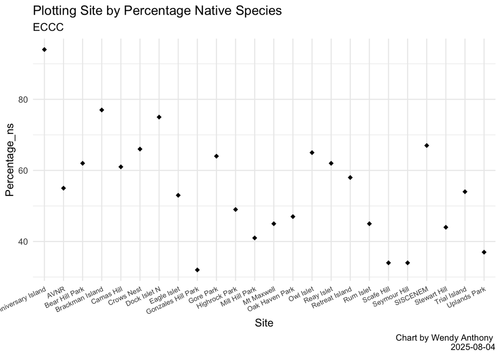

```r
site_natsp <- ggplot(goe_eccc,
                    aes(x = Site, y = Percentage_ns)) +
                    geom_point(shape = 18, size = 2) +
                    theme_minimal() + #get rid of grey background and tick marks
                    theme(legend.position="none") + #remove legend
                    theme(axis.text.x = element_text(angle = 25, vjust = 1, hjust=1, size = 7)) +
                    labs(title='Plotting Site by Percentage Native Species',
                      subtitle='ECCC',
                      caption = "Chart by Wendy Anthony \n 2025-08-04")
site_natsp
```

## 4.2 Site by Composite_Index

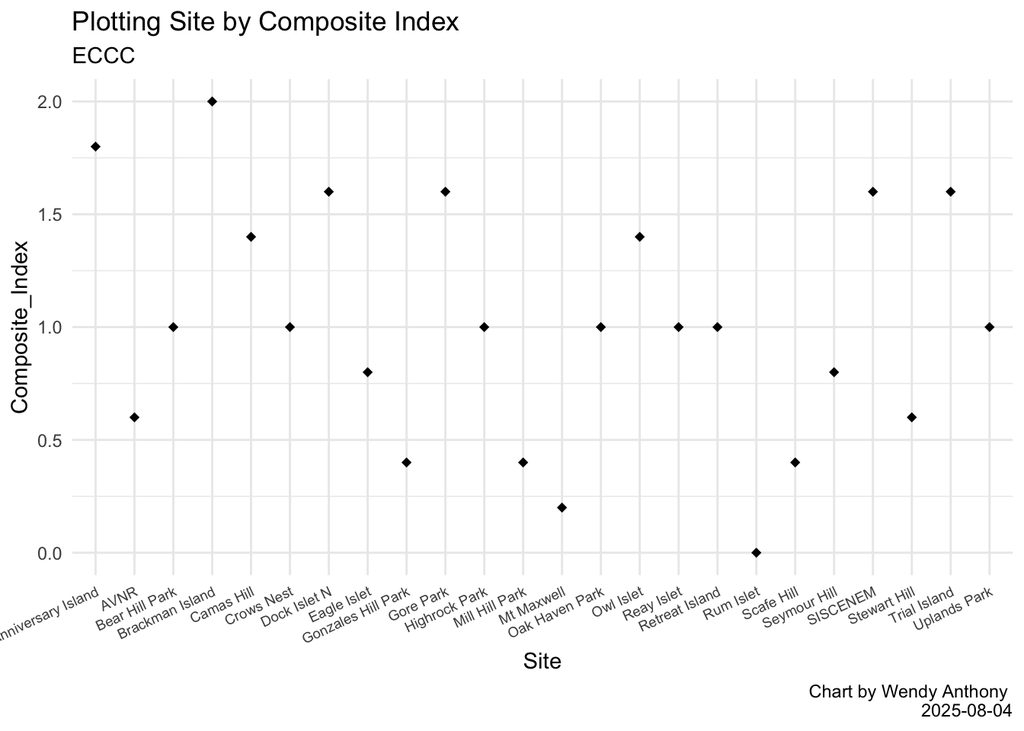

```r
site_natsp <- ggplot(goe_eccc,
                    aes(x = Site, y = Composite_Index)) +
                    geom_point(shape = 18, size = 2) +
                    theme_minimal() + #get rid of grey background and tick marks
                    theme(legend.position="none") + #remove legend
                    theme(axis.text.x = element_text(angle = 25, vjust = 1, hjust=1, size = 7)) +
                    labs(title='Plotting Site by Composite Index',
                      subtitle='ECCC',
                      caption = "Chart by Wendy Anthony \n 2025-08-04")
site_natsp
```

## 4.3 TEST DOESn’t Reorder Site by Restoration_Intensity

- note Reay Islet was showing a separate High, so in original csv I copied High value from another site, aslo Scafe Hill had a different low value …
- also all high values have a space in front … change all …
- Having trouble ordering Restoration_Intensity values … see next example

**Click to see results of `TEST`**

```r
# names(goe_eccc_sites_1)
# str(goe_eccc_sites_1)
# unique(goe_eccc_sites_1$Restoration_Intensity)
#
# # change character to factor
# goe_eccc_sites_1$Restoration_Intensity <- as.factor(goe_eccc_sites_1$Restoration_Intensity)
# # change factor to character
# goe_eccc_sites_1 <- data.frame(lapply(goe_eccc_sites_1, as.character), stringsAsFactors=FALSE)
#
# # WORKS !!!
# Restoration_Intensity_order <- c("high", "moderate", "low", "minimal")
# arranged_goe_eccc_sites_1 <- goe_eccc_sites_1 %>%
#   arrange(factor(Restoration_Intensity, levels = Restoration_Intensity_order))
# arranged_goe_eccc_sites_1
# str(arranged_goe_eccc_sites_1)
#
# # still not showing the order
# site_restInt <- ggplot(arranged_goe_eccc_sites_1,
#        aes(x = Site, y = Restoration_Intensity, color = Subregion)) +
#                     geom_point(shape = 18, size = 2) +
#   #geom_bar(stat="identity") +
#                     theme_minimal() + #get rid of grey background and tick marks
#                     theme(legend.position="bottom") + #remove legend
#                     theme(axis.text.x = element_text(angle = 25, vjust = 1, hjust=1, size = 7)) +
#                     labs(title='Plotting Site by Restoration_Intensity',
#                       subtitle='ECCC',
#                       caption = "Chart by Wendy Anthony \n 2025-08-20")
# site_restInt

# ggplotly(site_restInt)
```

## 4.4 ORDER NOT WORKING TEST Site by Restoration_Intensity and Exotic_species

```r
names(goe_eccc_sites_1)
```

```
##  [1] "Subregion"                    "Site"
##  [3] "Land_Manager"                 "Main_Restoration_Type"
##  [5] "Restoration_Intensity"        "Area_ha"
##  [7] "Lat"                          "Lng"
##  [9] "Proportion_of_native_species" "Cultural_species_richness"
## [11] "Exotic_species"               "Trampling"
## [13] "Herbivory"                    "Composite_Index"
## [15] "Year"                         "Percentage_ns"
```

```r
str(goe_eccc_sites_1)
```

```
## 'data.frame':    24 obs. of  16 variables:
##  $ Subregion                   : chr  "Gulf Islands" "Gulf Islands" "Saanich Peninsula" "Gulf Islands" ...
##  $ Site                        : chr  "Anniversary Island" "AVNR" "Bear Hill Park" "Brackman Island" ...
##  $ Land_Manager                : chr  "GINPR" "Saltspring conservancy" "CRD" "GINPR" ...
##  $ Main_Restoration_Type       : chr  "herbivore reduction" "herbivore reduction" "invasive removal" "invasive removal" ...
##  $ Restoration_Intensity       : chr  "high" "minimal" "low" "high" ...
##  $ Area_ha                     : num  4.39 20.54 3.8 4.41 10.1 ...
##  $ Lat                         : num  48.8 48.8 48.5 48.7 48.4 ...
##  $ Lng                         : num  -123 -123 -123 -123 -124 ...
##  $ Proportion_of_native_species: num  0.94 0.55 0.62 0.77 0.61 0.66 0.75 0.53 0.32 0.64 ...
##  $ Cultural_species_richness   : num  2.71 1.3 1.86 2.8 2.43 1.07 3.6 0.8 1 4.4 ...
##  $ Exotic_species              : num  0.17 57.19 24.46 11.17 27.19 ...
##  $ Trampling                   : num  5 4.7 7.57 5.4 7.71 1.64 12.2 16.6 10.4 6.2 ...
##  $ Herbivory                   : num  1.14 36.5 9.5 0 4.71 ...
##  $ Composite_Index             : num  1.8 0.6 1 2 1.4 1 1.6 0.8 0.4 1.6 ...
##  $ Year                        : int  2023 2023 2023 2023 2023 2023 2023 2023 2023 2023 ...
##  $ Percentage_ns               : num  94 55 62 77 61 66 75 53 32 64 ...
```

```r
# Step 1
desired_levels <- c("high", "moderate", "low", "minimal")
# create new df to create desired levels
goe_eccc_sites_2 <- goe_eccc_sites_1
# this changes data type from character to factor
goe_eccc_sites_2$Restoration_Intensity <- factor(goe_eccc_sites_1$Restoration_Intensity, levels = desired_levels)
print(levels(goe_eccc_sites_2$Restoration_Intensity)) # New order of levels
```

```
## [1] "high"     "moderate" "low"      "minimal"
```

```r
str(goe_eccc_sites_2)
```

```
## 'data.frame':    24 obs. of  16 variables:
##  $ Subregion                   : chr  "Gulf Islands" "Gulf Islands" "Saanich Peninsula" "Gulf Islands" ...
##  $ Site                        : chr  "Anniversary Island" "AVNR" "Bear Hill Park" "Brackman Island" ...
##  $ Land_Manager                : chr  "GINPR" "Saltspring conservancy" "CRD" "GINPR" ...
##  $ Main_Restoration_Type       : chr  "herbivore reduction" "herbivore reduction" "invasive removal" "invasive removal" ...
##  $ Restoration_Intensity       : Factor w/ 4 levels "high","moderate",..: 1 4 3 1 1 1 1 1 3 2 ...
##  $ Area_ha                     : num  4.39 20.54 3.8 4.41 10.1 ...
##  $ Lat                         : num  48.8 48.8 48.5 48.7 48.4 ...
##  $ Lng                         : num  -123 -123 -123 -123 -124 ...
##  $ Proportion_of_native_species: num  0.94 0.55 0.62 0.77 0.61 0.66 0.75 0.53 0.32 0.64 ...
##  $ Cultural_species_richness   : num  2.71 1.3 1.86 2.8 2.43 1.07 3.6 0.8 1 4.4 ...
##  $ Exotic_species              : num  0.17 57.19 24.46 11.17 27.19 ...
##  $ Trampling                   : num  5 4.7 7.57 5.4 7.71 1.64 12.2 16.6 10.4 6.2 ...
##  $ Herbivory                   : num  1.14 36.5 9.5 0 4.71 ...
##  $ Composite_Index             : num  1.8 0.6 1 2 1.4 1 1.6 0.8 0.4 1.6 ...
##  $ Year                        : int  2023 2023 2023 2023 2023 2023 2023 2023 2023 2023 ...
##  $ Percentage_ns               : num  94 55 62 77 61 66 75 53 32 64 ...
```

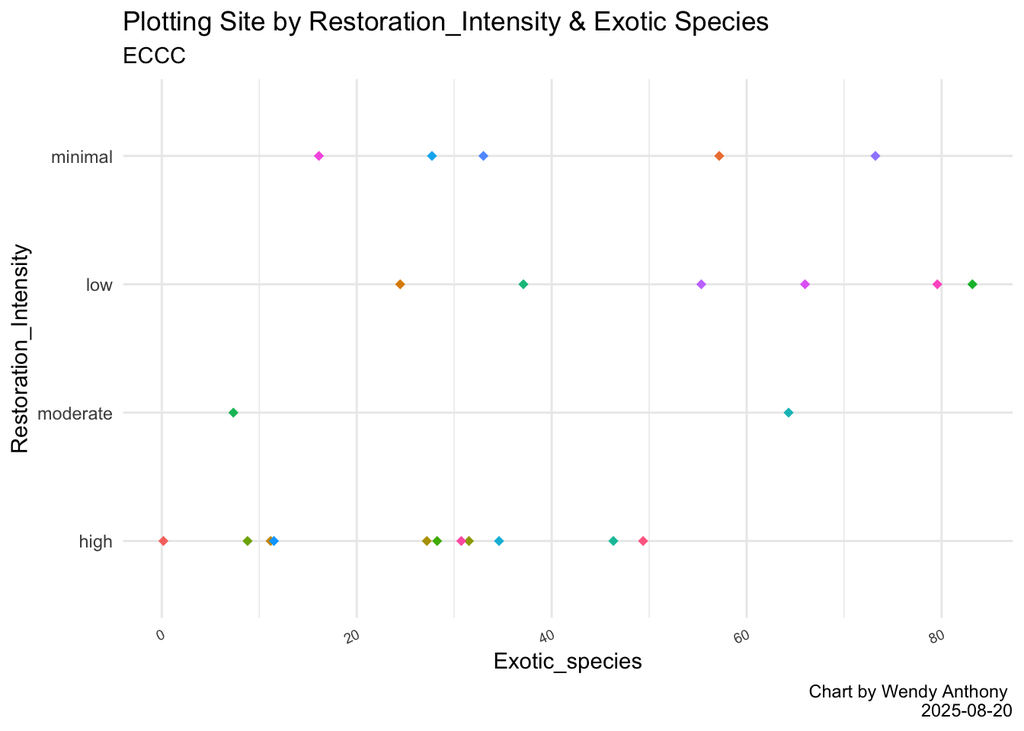

```r
# step 2
goe_eccc_sites_2 <- goe_eccc_sites_2[order(goe_eccc_sites_2$Restoration_Intensity),]

site_restInt_exotic <- ggplot(goe_eccc_sites_2,
       aes(x = Exotic_species, y = Restoration_Intensity, color = Site)) +
                    geom_point(shape = 18, size = 2) +
  #geom_bar(stat="identity") +
                    theme_minimal() + #get rid of grey background and tick marks
                    theme(legend.position="none") + #remove legend legen won't stick to bottom with ggplotly
                    theme(axis.text.x = element_text(angle = 25, vjust = 1, hjust=1, size = 7)) +
                    labs(title='Plotting Site by Restoration_Intensity & Exotic Species',
                      subtitle='ECCC',
                      caption = "Chart by Wendy Anthony \n 2025-08-20")
site_restInt_exotic
```

```r
# ggplotly(site_restInt_exotic)
# change ggplotly legend to bottom
  # %>%
 #      plotly::layout(legend=list(x=0,
 #                                 xanchor='left',
 #                                 yanchor='bottom',
 #                                 orientation='h'))
```

## 4.5 ORDER WORKs Point Plot Site by Restoration_Intensity

```r
names(goe_eccc_sites_1)
```

```
##  [1] "Subregion"                    "Site"
##  [3] "Land_Manager"                 "Main_Restoration_Type"
##  [5] "Restoration_Intensity"        "Area_ha"
##  [7] "Lat"                          "Lng"
##  [9] "Proportion_of_native_species" "Cultural_species_richness"
## [11] "Exotic_species"               "Trampling"
## [13] "Herbivory"                    "Composite_Index"
## [15] "Year"                         "Percentage_ns"
```

```r
# Reorder following a precise order
# https://r-graph-gallery.com/267-reorder-a-variable-in-ggplot2.html
# https://stackoverflow.com/questions/18413756/re-ordering-factor-levels-in-data-frame
# mydf$task <- factor(mydf$task, levels = c("up", "down", "left", "right", "front", "back"))
#goe_eccc_sites_1$Restoration_Intensity <- factor(goe_eccc_sites_1$Restoration_Intensity, levels = #c("high", "moderate", "low", "minimal"))
str(goe_eccc_sites_1)
```

```
## 'data.frame':    24 obs. of  16 variables:
##  $ Subregion                   : chr  "Gulf Islands" "Gulf Islands" "Saanich Peninsula" "Gulf Islands" ...
##  $ Site                        : chr  "Anniversary Island" "AVNR" "Bear Hill Park" "Brackman Island" ...
##  $ Land_Manager                : chr  "GINPR" "Saltspring conservancy" "CRD" "GINPR" ...
##  $ Main_Restoration_Type       : chr  "herbivore reduction" "herbivore reduction" "invasive removal" "invasive removal" ...
##  $ Restoration_Intensity       : chr  "high" "minimal" "low" "high" ...
##  $ Area_ha                     : num  4.39 20.54 3.8 4.41 10.1 ...
##  $ Lat                         : num  48.8 48.8 48.5 48.7 48.4 ...
##  $ Lng                         : num  -123 -123 -123 -123 -124 ...
##  $ Proportion_of_native_species: num  0.94 0.55 0.62 0.77 0.61 0.66 0.75 0.53 0.32 0.64 ...
##  $ Cultural_species_richness   : num  2.71 1.3 1.86 2.8 2.43 1.07 3.6 0.8 1 4.4 ...
##  $ Exotic_species              : num  0.17 57.19 24.46 11.17 27.19 ...
##  $ Trampling                   : num  5 4.7 7.57 5.4 7.71 1.64 12.2 16.6 10.4 6.2 ...
##  $ Herbivory                   : num  1.14 36.5 9.5 0 4.71 ...
##  $ Composite_Index             : num  1.8 0.6 1 2 1.4 1 1.6 0.8 0.4 1.6 ...
##  $ Year                        : int  2023 2023 2023 2023 2023 2023 2023 2023 2023 2023 ...
##  $ Percentage_ns               : num  94 55 62 77 61 66 75 53 32 64 ...
```

```r
# change character to factor
# str(goe_eccc_sites_1)
# goe_eccc_sites_1$Restoration_Intensity <- as.factor(goe_eccc_sites_1$Restoration_Intensity)
# str(goe_eccc_sites_1)
# # change factor to character
# goe_eccc_sites_1 <- data.frame(lapply(goe_eccc_sites_1, as.character), stringsAsFactors=FALSE)
# str(goe_eccc_sites_1)

# Step 1
desired_levels <- c("high", "moderate", "low", "minimal")
# create new df to create desired levels
goe_eccc_sites_2 <- goe_eccc_sites_1
# this changes data type from character to factor
goe_eccc_sites_2$Restoration_Intensity <- factor(goe_eccc_sites_1$Restoration_Intensity, levels = desired_levels)
print(levels(goe_eccc_sites_2$Restoration_Intensity)) # New order of levels
```

```
## [1] "high"     "moderate" "low"      "minimal"
```

```r
str(goe_eccc_sites_2)
```

```
## 'data.frame':    24 obs. of  16 variables:
##  $ Subregion                   : chr  "Gulf Islands" "Gulf Islands" "Saanich Peninsula" "Gulf Islands" ...
##  $ Site                        : chr  "Anniversary Island" "AVNR" "Bear Hill Park" "Brackman Island" ...
##  $ Land_Manager                : chr  "GINPR" "Saltspring conservancy" "CRD" "GINPR" ...
##  $ Main_Restoration_Type       : chr  "herbivore reduction" "herbivore reduction" "invasive removal" "invasive removal" ...
##  $ Restoration_Intensity       : Factor w/ 4 levels "high","moderate",..: 1 4 3 1 1 1 1 1 3 2 ...
##  $ Area_ha                     : num  4.39 20.54 3.8 4.41 10.1 ...
##  $ Lat                         : num  48.8 48.8 48.5 48.7 48.4 ...
##  $ Lng                         : num  -123 -123 -123 -123 -124 ...
##  $ Proportion_of_native_species: num  0.94 0.55 0.62 0.77 0.61 0.66 0.75 0.53 0.32 0.64 ...
##  $ Cultural_species_richness   : num  2.71 1.3 1.86 2.8 2.43 1.07 3.6 0.8 1 4.4 ...
##  $ Exotic_species              : num  0.17 57.19 24.46 11.17 27.19 ...
##  $ Trampling                   : num  5 4.7 7.57 5.4 7.71 1.64 12.2 16.6 10.4 6.2 ...
##  $ Herbivory                   : num  1.14 36.5 9.5 0 4.71 ...
##  $ Composite_Index             : num  1.8 0.6 1 2 1.4 1 1.6 0.8 0.4 1.6 ...
##  $ Year                        : int  2023 2023 2023 2023 2023 2023 2023 2023 2023 2023 ...
##  $ Percentage_ns               : num  94 55 62 77 61 66 75 53 32 64 ...
```

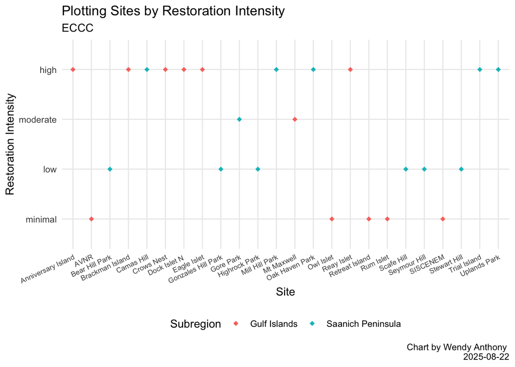

```r
# step 2
goe_eccc_sites_2 <- goe_eccc_sites_2[order(goe_eccc_sites_2$Restoration_Intensity),]

# values in order now -- ?? how to change to reverse order
site_restInt <- ggplot(goe_eccc_sites_2,
       aes(x = Site, y = reorder(Restoration_Intensity, desc(Restoration_Intensity)), color = Subregion)) +
  # reorder y variable axis
  # https://stackoverflow.com/questions/28391850/reverse-order-of-discrete-y-axis-in-ggplot2s
# y = Restoration_Intensity
                    geom_point(shape = 18, size = 2) +
  #geom_bar(stat="identity") +
  # Replace default palette of pink & blue
  scale_fill_brewer(palette = "Dark2") +
                    theme_minimal() + #get rid of grey background and tick marks
                    theme(legend.position="bottom") + #remove legend
                    theme(axis.text.x = element_text(angle = 25, vjust = 1, hjust=1, size = 7)) +
                    labs(title='Plotting Sites by Restoration Intensity',
                      subtitle='ECCC',
                      caption = "Chart by Wendy Anthony \n 2025-08-22", x = "Site", y = "Restoration Intensity")

site_restInt
```

```r
ggplotly(site_restInt)
```

[interactive chart not shown]

## 4.6 Change x axis ORDER WORKs Point Plot Site by Restoration_Intensity

```r
names(goe_eccc_sites_1)
```

```
##  [1] "Subregion"                    "Site"
##  [3] "Land_Manager"                 "Main_Restoration_Type"
##  [5] "Restoration_Intensity"        "Area_ha"
##  [7] "Lat"                          "Lng"
##  [9] "Proportion_of_native_species" "Cultural_species_richness"
## [11] "Exotic_species"               "Trampling"
## [13] "Herbivory"                    "Composite_Index"
## [15] "Year"                         "Percentage_ns"
```

```r
# Reorder following a precise order
# https://r-graph-gallery.com/267-reorder-a-variable-in-ggplot2.html
# https://stackoverflow.com/questions/18413756/re-ordering-factor-levels-in-data-frame
# mydf$task <- factor(mydf$task, levels = c("up", "down", "left", "right", "front", "back"))
#goe_eccc_sites_1$Restoration_Intensity <- factor(goe_eccc_sites_1$Restoration_Intensity, levels = #c("high", "moderate", "low", "minimal"))
str(goe_eccc_sites_1)
```

```
## 'data.frame':    24 obs. of  16 variables:
##  $ Subregion                   : chr  "Gulf Islands" "Gulf Islands" "Saanich Peninsula" "Gulf Islands" ...
##  $ Site                        : chr  "Anniversary Island" "AVNR" "Bear Hill Park" "Brackman Island" ...
##  $ Land_Manager                : chr  "GINPR" "Saltspring conservancy" "CRD" "GINPR" ...
##  $ Main_Restoration_Type       : chr  "herbivore reduction" "herbivore reduction" "invasive removal" "invasive removal" ...
##  $ Restoration_Intensity       : chr  "high" "minimal" "low" "high" ...
##  $ Area_ha                     : num  4.39 20.54 3.8 4.41 10.1 ...
##  $ Lat                         : num  48.8 48.8 48.5 48.7 48.4 ...
##  $ Lng                         : num  -123 -123 -123 -123 -124 ...
##  $ Proportion_of_native_species: num  0.94 0.55 0.62 0.77 0.61 0.66 0.75 0.53 0.32 0.64 ...
##  $ Cultural_species_richness   : num  2.71 1.3 1.86 2.8 2.43 1.07 3.6 0.8 1 4.4 ...
##  $ Exotic_species              : num  0.17 57.19 24.46 11.17 27.19 ...
##  $ Trampling                   : num  5 4.7 7.57 5.4 7.71 1.64 12.2 16.6 10.4 6.2 ...
##  $ Herbivory                   : num  1.14 36.5 9.5 0 4.71 ...
##  $ Composite_Index             : num  1.8 0.6 1 2 1.4 1 1.6 0.8 0.4 1.6 ...
##  $ Year                        : int  2023 2023 2023 2023 2023 2023 2023 2023 2023 2023 ...
##  $ Percentage_ns               : num  94 55 62 77 61 66 75 53 32 64 ...
```

```r
# change character to factor
# str(goe_eccc_sites_1)
# goe_eccc_sites_1$Restoration_Intensity <- as.factor(goe_eccc_sites_1$Restoration_Intensity)
# str(goe_eccc_sites_1)
# # change factor to character
# goe_eccc_sites_1 <- data.frame(lapply(goe_eccc_sites_1, as.character), stringsAsFactors=FALSE)
# str(goe_eccc_sites_1)

# Step 1
desired_levels <- c("high", "moderate", "low", "minimal")
# create new df to create desired levels
goe_eccc_sites_2 <- goe_eccc_sites_1
# this changes data type from character to factor
goe_eccc_sites_2$Restoration_Intensity <- factor(goe_eccc_sites_1$Restoration_Intensity, levels = desired_levels)
print(levels(goe_eccc_sites_2$Restoration_Intensity)) # New order of levels
```

```
## [1] "high"     "moderate" "low"      "minimal"
```

```r
str(goe_eccc_sites_2)
```

```
## 'data.frame':    24 obs. of  16 variables:
##  $ Subregion                   : chr  "Gulf Islands" "Gulf Islands" "Saanich Peninsula" "Gulf Islands" ...
##  $ Site                        : chr  "Anniversary Island" "AVNR" "Bear Hill Park" "Brackman Island" ...
##  $ Land_Manager                : chr  "GINPR" "Saltspring conservancy" "CRD" "GINPR" ...
##  $ Main_Restoration_Type       : chr  "herbivore reduction" "herbivore reduction" "invasive removal" "invasive removal" ...
##  $ Restoration_Intensity       : Factor w/ 4 levels "high","moderate",..: 1 4 3 1 1 1 1 1 3 2 ...
##  $ Area_ha                     : num  4.39 20.54 3.8 4.41 10.1 ...
##  $ Lat                         : num  48.8 48.8 48.5 48.7 48.4 ...
##  $ Lng                         : num  -123 -123 -123 -123 -124 ...
##  $ Proportion_of_native_species: num  0.94 0.55 0.62 0.77 0.61 0.66 0.75 0.53 0.32 0.64 ...
##  $ Cultural_species_richness   : num  2.71 1.3 1.86 2.8 2.43 1.07 3.6 0.8 1 4.4 ...
##  $ Exotic_species              : num  0.17 57.19 24.46 11.17 27.19 ...
##  $ Trampling                   : num  5 4.7 7.57 5.4 7.71 1.64 12.2 16.6 10.4 6.2 ...
##  $ Herbivory                   : num  1.14 36.5 9.5 0 4.71 ...
##  $ Composite_Index             : num  1.8 0.6 1 2 1.4 1 1.6 0.8 0.4 1.6 ...
##  $ Year                        : int  2023 2023 2023 2023 2023 2023 2023 2023 2023 2023 ...
##  $ Percentage_ns               : num  94 55 62 77 61 66 75 53 32 64 ...
```

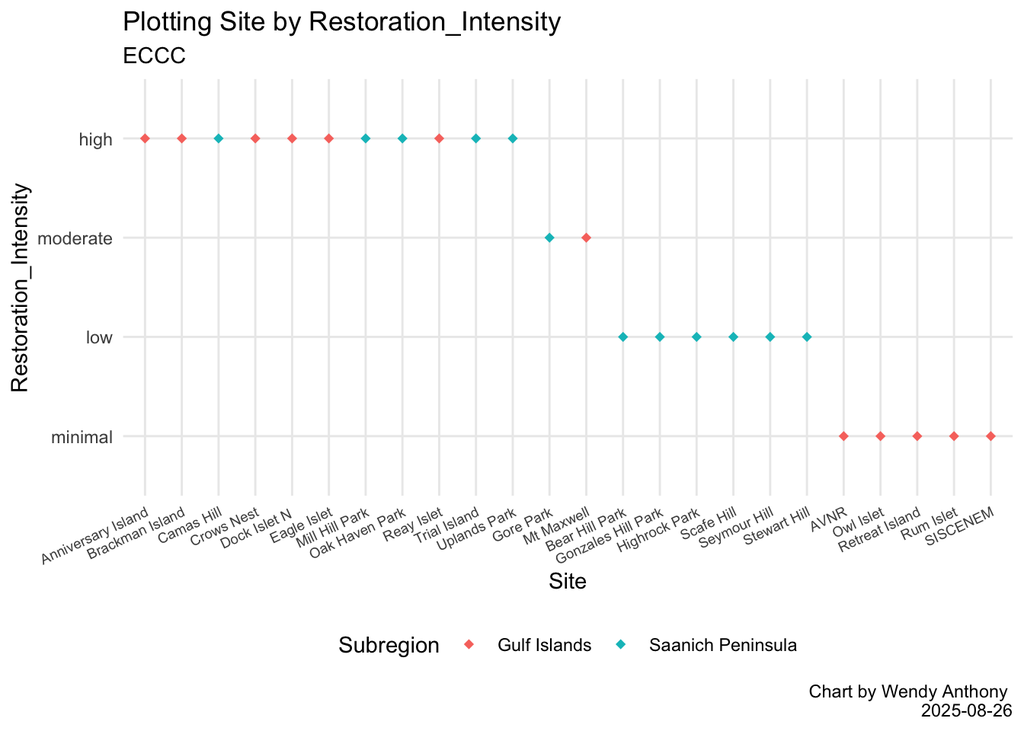

```r
# step 2
goe_eccc_sites_2 <- goe_eccc_sites_2[order(goe_eccc_sites_2$Restoration_Intensity),]

# values in order now -- ?? how to change to reverse order
site_restInt_x <- ggplot(goe_eccc_sites_2,
       aes(x = reorder(Site,
                       # -desc reverses descending
                       -desc(Restoration_Intensity)),
           y = reorder(Restoration_Intensity, desc(Restoration_Intensity)), color = Subregion)) +
  # reorder y variable axis
  # https://stackoverflow.com/questions/28391850/reverse-order-of-discrete-y-axis-in-ggplot2s
# y = Restoration_Intensity
                    geom_point(shape = 18, size = 2) +
  #geom_bar(stat="identity") +
  # Replace default palette of pink & blue
  # makes ggploty legend show (Saanich Peninsula,1)
#  scale_fill_brewer(palette = "Dark2") +
                    theme_minimal() + #get rid of grey background and tick marks
                    theme(legend.position="bottom") + #remove legend
                    theme(axis.text.x = element_text(angle = 25, vjust = 1, hjust=1, size = 7)) +
                    labs(title='Plotting Site by Restoration_Intensity',
                      subtitle='ECCC',
                      caption = "Chart by Wendy Anthony \n 2025-08-26",
                      x = "Site", y = "Restoration_Intensity")
site_restInt_x
```

```r
ggplotly(site_restInt_x)
```

[interactive chart not shown]

## 4.7 BAR Plot WORKS Site by Restoration_Intensity

```r
names(goe_eccc_sites_1)
```

```
##  [1] "Subregion"                    "Site"
##  [3] "Land_Manager"                 "Main_Restoration_Type"
##  [5] "Restoration_Intensity"        "Area_ha"
##  [7] "Lat"                          "Lng"
##  [9] "Proportion_of_native_species" "Cultural_species_richness"
## [11] "Exotic_species"               "Trampling"
## [13] "Herbivory"                    "Composite_Index"
## [15] "Year"                         "Percentage_ns"
```

```r
# Reorder following a precise order
# https://r-graph-gallery.com/267-reorder-a-variable-in-ggplot2.html
# https://stackoverflow.com/questions/18413756/re-ordering-factor-levels-in-data-frame
# mydf$task <- factor(mydf$task, levels = c("up", "down", "left", "right", "front", "back"))
#goe_eccc_sites_1$Restoration_Intensity <- factor(goe_eccc_sites_1$Restoration_Intensity, levels = #c("high", "moderate", "low", "minimal"))
str(goe_eccc_sites_1)
```

```
## 'data.frame':    24 obs. of  16 variables:
##  $ Subregion                   : chr  "Gulf Islands" "Gulf Islands" "Saanich Peninsula" "Gulf Islands" ...
##  $ Site                        : chr  "Anniversary Island" "AVNR" "Bear Hill Park" "Brackman Island" ...
##  $ Land_Manager                : chr  "GINPR" "Saltspring conservancy" "CRD" "GINPR" ...
##  $ Main_Restoration_Type       : chr  "herbivore reduction" "herbivore reduction" "invasive removal" "invasive removal" ...
##  $ Restoration_Intensity       : chr  "high" "minimal" "low" "high" ...
##  $ Area_ha                     : num  4.39 20.54 3.8 4.41 10.1 ...
##  $ Lat                         : num  48.8 48.8 48.5 48.7 48.4 ...
##  $ Lng                         : num  -123 -123 -123 -123 -124 ...
##  $ Proportion_of_native_species: num  0.94 0.55 0.62 0.77 0.61 0.66 0.75 0.53 0.32 0.64 ...
##  $ Cultural_species_richness   : num  2.71 1.3 1.86 2.8 2.43 1.07 3.6 0.8 1 4.4 ...
##  $ Exotic_species              : num  0.17 57.19 24.46 11.17 27.19 ...
##  $ Trampling                   : num  5 4.7 7.57 5.4 7.71 1.64 12.2 16.6 10.4 6.2 ...
##  $ Herbivory                   : num  1.14 36.5 9.5 0 4.71 ...
##  $ Composite_Index             : num  1.8 0.6 1 2 1.4 1 1.6 0.8 0.4 1.6 ...
##  $ Year                        : int  2023 2023 2023 2023 2023 2023 2023 2023 2023 2023 ...
##  $ Percentage_ns               : num  94 55 62 77 61 66 75 53 32 64 ...
```

```r
# change character to factor
# str(goe_eccc_sites_1)
# goe_eccc_sites_1$Restoration_Intensity <- as.factor(goe_eccc_sites_1$Restoration_Intensity)
# str(goe_eccc_sites_1)
# # change factor to character
# goe_eccc_sites_1 <- data.frame(lapply(goe_eccc_sites_1, as.character), stringsAsFactors=FALSE)
# str(goe_eccc_sites_1)

# Step 1
desired_levels <- c("high", "moderate", "low", "minimal")
# this changes data type from character to factor
goe_eccc_sites_2$Restoration_Intensity <- factor(goe_eccc_sites_1$Restoration_Intensity, levels = desired_levels)
print(levels(goe_eccc_sites_2$Restoration_Intensity)) # New order of levels
```

```
## [1] "high"     "moderate" "low"      "minimal"
```

```r
str(goe_eccc_sites_2)
```

```
## 'data.frame':    24 obs. of  16 variables:
##  $ Subregion                   : chr  "Gulf Islands" "Gulf Islands" "Saanich Peninsula" "Gulf Islands" ...
##  $ Site                        : chr  "Anniversary Island" "Brackman Island" "Camas Hill" "Crows Nest" ...
##  $ Land_Manager                : chr  "GINPR" "GINPR" "HAT" "Trinity Western University" ...
##  $ Main_Restoration_Type       : chr  "herbivore reduction" "invasive removal" "invasive removal" "herbivore reduction" ...
##  $ Restoration_Intensity       : Factor w/ 4 levels "high","moderate",..: 1 4 3 1 1 1 1 1 3 2 ...
##  $ Area_ha                     : num  4.39 4.41 10.1 15.34 0.54 ...
##  $ Lat                         : num  48.8 48.7 48.4 48.8 48.7 ...
##  $ Lng                         : num  -123 -123 -124 -123 -123 ...
##  $ Proportion_of_native_species: num  0.94 0.77 0.61 0.66 0.75 0.53 0.41 0.47 0.62 0.54 ...
##  $ Cultural_species_richness   : num  2.71 2.8 2.43 1.07 3.6 0.8 1.56 1.5 3.6 3.57 ...
##  $ Exotic_species              : num  0.17 11.17 27.19 31.51 8.8 ...
##  $ Trampling                   : num  5 5.4 7.71 1.64 12.2 ...
##  $ Herbivory                   : num  1.14 0 4.71 26.71 0.1 ...
##  $ Composite_Index             : num  1.8 2 1.4 1 1.6 0.8 0.4 1 1 1.6 ...
##  $ Year                        : int  2023 2023 2023 2023 2023 2023 2023 2023 2023 2023 ...
##  $ Percentage_ns               : num  94 77 61 66 75 53 41 47 62 54 ...
```

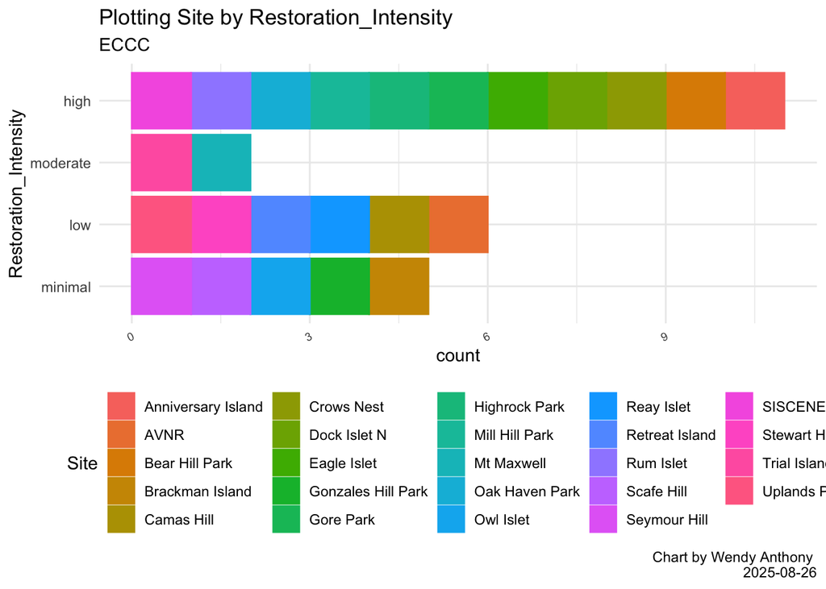

```r
# step 2
goe_eccc_sites_2 <- goe_eccc_sites_2[order(goe_eccc_sites_2$Restoration_Intensity),]

# values in order now -- ?? how to change to reverse order
site_restInt_bar <- ggplot(goe_eccc_sites_2,
       aes(y = reorder(Restoration_Intensity, desc(Restoration_Intensity)), color = Site, fill = Site)) +
  # reorder y variable axis
  # https://stackoverflow.com/questions/28391850/reverse-order-of-discrete-y-axis-in-ggplot2s
# y = Restoration_Intensity
                    geom_bar() +
  #geom_bar(stat="identity") +
                    theme_minimal() + #get rid of grey background and tick marks
                    theme(legend.position="bottom") + #remove legend
                    theme(axis.text.x = element_text(angle = 25, vjust = 1, hjust=1, size = 7)) +
                    labs(title='Plotting Site by Restoration_Intensity',
                      subtitle='ECCC',
                      caption = "Chart by Wendy Anthony \n 2025-08-26", y = "Restoration_Intensity")
site_restInt_bar
```

```r
ggplotly(site_restInt_bar)
```

[interactive chart not shown]

## 4.8 Violin Subregion by Exotic_species

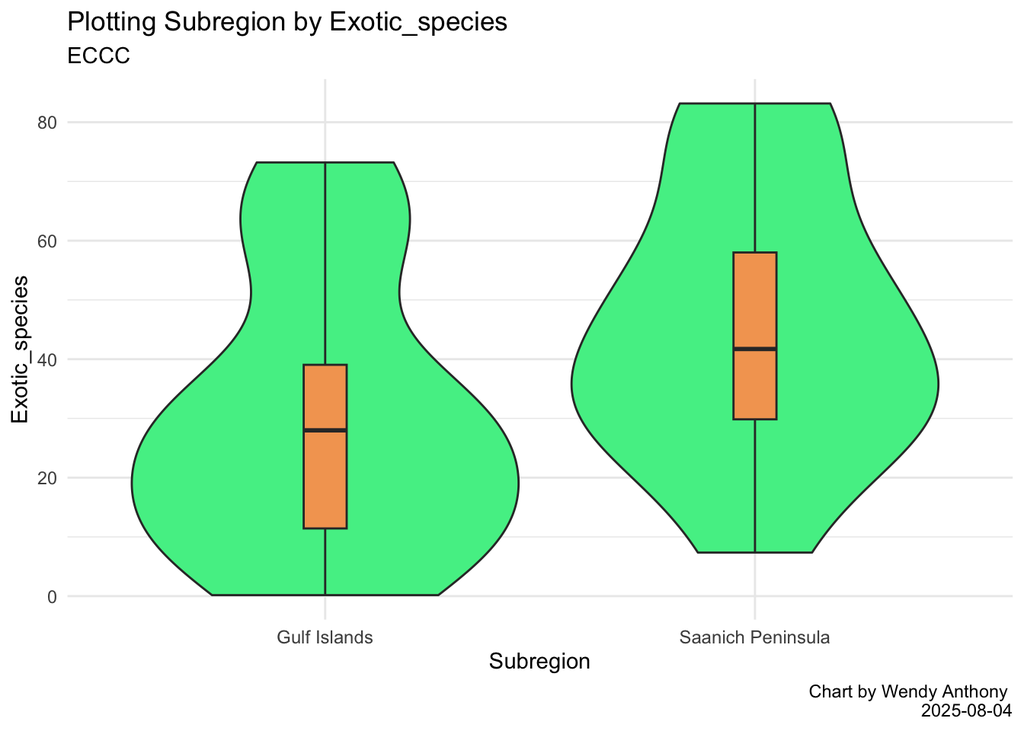

```r
subregion_exsp <- ggplot(goe_eccc,
                    aes(x = Subregion, y = Exotic_species)) +
                    geom_violin(fill = "seagreen2") +
                    geom_boxplot(width = 0.1, fill = "sandybrown") +
                    theme_minimal() + #get rid of grey background and tick marks
                    theme(legend.position="none") + #remove legend
                    theme(axis.text.x = element_text(vjust = 1, size = 9)) +
                    labs(title='Plotting Subregion by Exotic_species',
                      subtitle='ECCC',
                      caption = "Chart by Wendy Anthony \n 2025-08-04")
subregion_exsp
```

```r
# plotly won't work here
```

## 4.9 Violin Subregion by Percentage_ns

```r
names(goe_eccc)
```

```
##  [1] "Subregion"                    "Site"
##  [3] "Proportion_of_native_species" "Cultural_species_richness"
##  [5] "Exotic_species"               "Trampling"
##  [7] "Herbivory"                    "Composite_Index"
##  [9] "Year"                         "Percentage_ns"
```

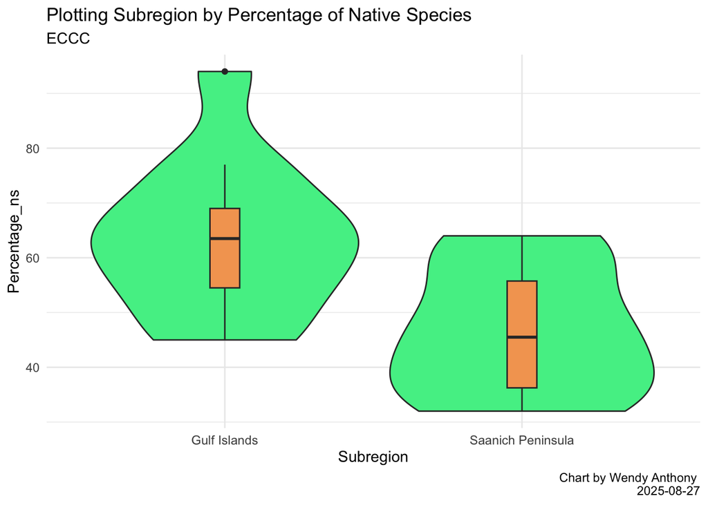

```r
subregion_nsp <- ggplot(goe_eccc,
                    aes(x = Subregion, y = Percentage_ns)) +
                    geom_violin(fill = "seagreen2") +
                    geom_boxplot(width = 0.1, fill = "sandybrown") +
                    theme_minimal() + #get rid of grey background and tick marks
                    theme(legend.position="none") + #remove legend
                    theme(axis.text.x = element_text(vjust = 1, size = 9)) +
                    labs(title='Plotting Subregion by Percentage of Native Species',
                      subtitle='ECCC',
                      caption = "Chart by Wendy Anthony \n 2025-08-27")
subregion_nsp
```

```r
# plotly won't work here
```

## 4.10 Cowplot Violin Subregion plot_grid

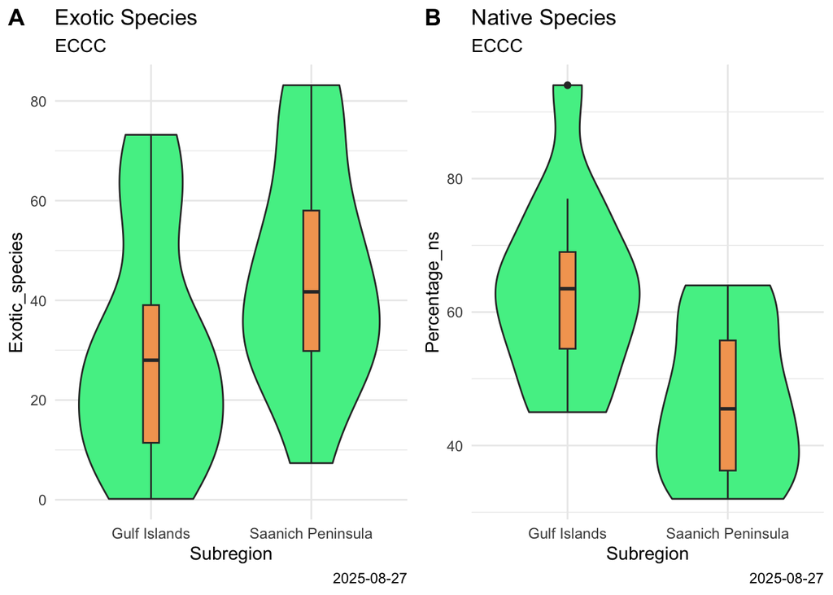

```r
library(cowplot)

subregion_exsp_1 <- subregion_exsp + labs(title='Exotic Species',
                      subtitle='ECCC',
                      caption = "2025-08-27")

subregion_nsp_1 <- subregion_nsp + labs(title='Native Species',
                      subtitle='ECCC',
                      caption = "2025-08-27")

plot_grid(subregion_exsp_1, subregion_nsp_1, labels = "AUTO")
```

## 4.11 TEST NOTWorking Bar Chart Subregion by Restoration_Intensity

```r
names(goe_eccc_sites_1)
```

```
##  [1] "Subregion"                    "Site"
##  [3] "Land_Manager"                 "Main_Restoration_Type"
##  [5] "Restoration_Intensity"        "Area_ha"
##  [7] "Lat"                          "Lng"
##  [9] "Proportion_of_native_species" "Cultural_species_richness"
## [11] "Exotic_species"               "Trampling"
## [13] "Herbivory"                    "Composite_Index"
## [15] "Year"                         "Percentage_ns"
```

```r
str(goe_eccc_sites_1)
```

```
## 'data.frame':    24 obs. of  16 variables:
##  $ Subregion                   : chr  "Gulf Islands" "Gulf Islands" "Saanich Peninsula" "Gulf Islands" ...
##  $ Site                        : chr  "Anniversary Island" "AVNR" "Bear Hill Park" "Brackman Island" ...
##  $ Land_Manager                : chr  "GINPR" "Saltspring conservancy" "CRD" "GINPR" ...
##  $ Main_Restoration_Type       : chr  "herbivore reduction" "herbivore reduction" "invasive removal" "invasive removal" ...
##  $ Restoration_Intensity       : chr  "high" "minimal" "low" "high" ...
##  $ Area_ha                     : num  4.39 20.54 3.8 4.41 10.1 ...
##  $ Lat                         : num  48.8 48.8 48.5 48.7 48.4 ...
##  $ Lng                         : num  -123 -123 -123 -123 -124 ...
##  $ Proportion_of_native_species: num  0.94 0.55 0.62 0.77 0.61 0.66 0.75 0.53 0.32 0.64 ...
##  $ Cultural_species_richness   : num  2.71 1.3 1.86 2.8 2.43 1.07 3.6 0.8 1 4.4 ...
##  $ Exotic_species              : num  0.17 57.19 24.46 11.17 27.19 ...
##  $ Trampling                   : num  5 4.7 7.57 5.4 7.71 1.64 12.2 16.6 10.4 6.2 ...
##  $ Herbivory                   : num  1.14 36.5 9.5 0 4.71 ...
##  $ Composite_Index             : num  1.8 0.6 1 2 1.4 1 1.6 0.8 0.4 1.6 ...
##  $ Year                        : int  2023 2023 2023 2023 2023 2023 2023 2023 2023 2023 ...
##  $ Percentage_ns               : num  94 55 62 77 61 66 75 53 32 64 ...
```

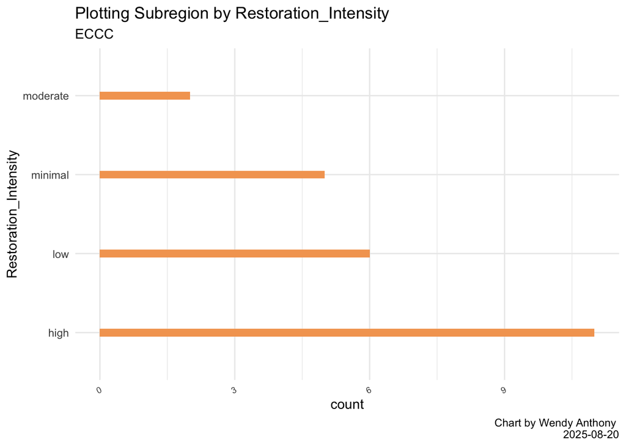

```r
subregion_restInt <- ggplot(goe_eccc_sites_1,
                    aes(y = Restoration_Intensity)) +
#                    geom_violin(fill = "seagreen2") +
                    geom_bar(width = 0.1, fill = "sandybrown") +
                    theme_minimal() + #get rid of grey background and tick marks
                    theme(legend.position="none") + #remove legend
                    theme(axis.text.x = element_text(angle = 25, vjust = 1, hjust=1, size = 7)) +
                    labs(title='Plotting Subregion by Restoration_Intensity',
                      subtitle='ECCC',
                      caption = "Chart by Wendy Anthony \n 2025-08-20")
subregion_restInt
```

```r
ggplotly()
```

[interactive chart not shown]

```r
# plotly won't work here
```

## 4.12 Subregion by Proportion_of_native_species

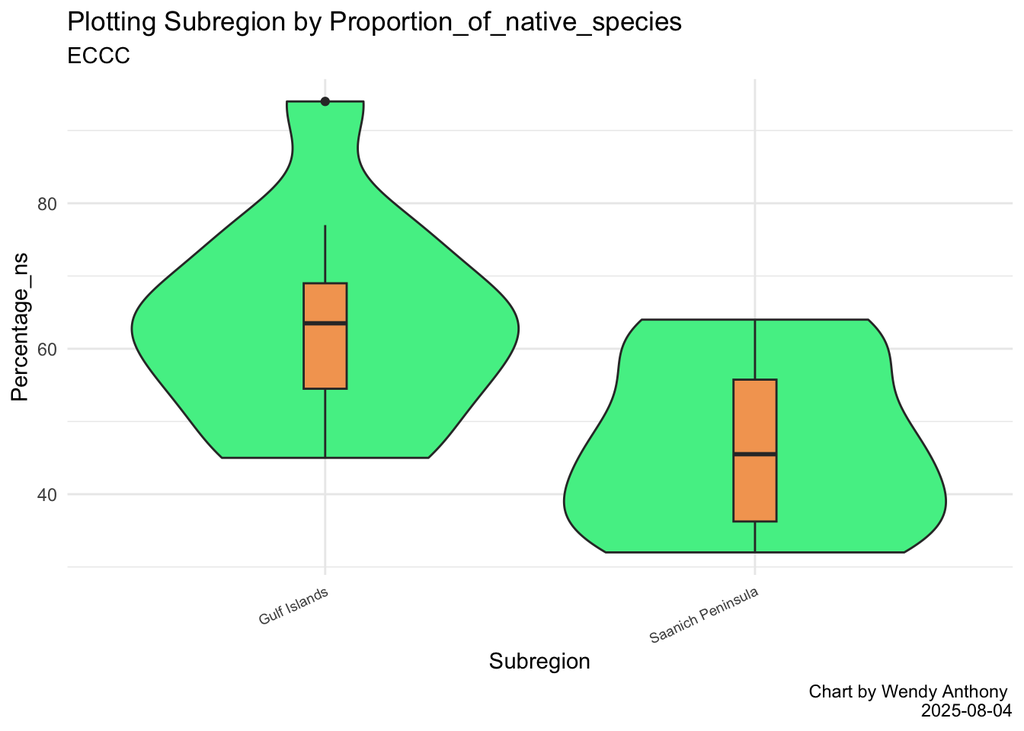

```r
subregion_natsp <- ggplot(goe_eccc_1,
                    aes(x = Subregion, y = Percentage_ns)) +
                    geom_violin(fill = "seagreen2") +
                    geom_boxplot(width = 0.1, fill = "sandybrown") +
                    theme_minimal() + #get rid of grey background and tick marks
                    theme(legend.position="none") + #remove legend
                    theme(axis.text.x = element_text(angle = 25, vjust = 1, hjust=1, size = 7)) +
                    labs(title='Plotting Subregion by Proportion_of_native_species',
                      subtitle='ECCC',
                      caption = "Chart by Wendy Anthony \n 2025-08-04")
subregion_natsp
```

## 4.13 —

# 5 Plots by Separate Sites

- use pivot_longer() for single row with multiple columns convert to long

## 5.1 pivot longer one row to long df

```r
colnames(goe_eccc_1)
```

```
##  [1] "Subregion"                    "Site"
##  [3] "Proportion_of_native_species" "Cultural_species_richness"
##  [5] "Exotic_species"               "Trampling"
##  [7] "Herbivory"                    "Composite_Index"
##  [9] "Year"                         "Percentage_ns"
```

```r
# choose index row from data sorted alphabetically
# delete first 2 columns as they can't be characters ? also Proportion to leave Percentage
# delete year column

# Anniversary_Island
Anniversary_Island <- goe_eccc_1[1, ]
Anniversary_Island
```

```
##      Subregion               Site Proportion_of_native_species
## 1 Gulf Islands Anniversary Island                         0.94
##   Cultural_species_richness Exotic_species Trampling Herbivory Composite_Index
## 1                      2.71           0.17         5      1.14             1.8
##   Year Percentage_ns
## 1 2023            94
```

```r
Anniversary_Island <- Anniversary_Island[, -c(1,2,9)]
Anniversary_Island_long <- Anniversary_Island %>% pivot_longer(everything(), names_to = "variable", values_to = "value")
Anniversary_Island_long
```

```
## # A tibble: 7 × 2
##   variable                     value
##   <chr>                        <dbl>
## 1 Proportion_of_native_species  0.94
## 2 Cultural_species_richness     2.71
## 3 Exotic_species                0.17
## 4 Trampling                     5
## 5 Herbivory                     1.14
## 6 Composite_Index               1.8
## 7 Percentage_ns                94
```

```r
# Gonzales
Gonzales <- goe_eccc_1[15, ]
Gonzales
```

```
##       Subregion      Site Proportion_of_native_species
## 15 Gulf Islands Owl Islet                         0.65
##    Cultural_species_richness Exotic_species Trampling Herbivory Composite_Index
## 15                         2          27.72     10.67      0.67             1.4
##    Year Percentage_ns
## 15 2023            65
```

```r
Gonzales <- Gonzales[, -c(1,2,9)]
Gonzales
```

```
##    Proportion_of_native_species Cultural_species_richness Exotic_species
## 15                         0.65                         2          27.72
##    Trampling Herbivory Composite_Index Percentage_ns
## 15     10.67      0.67             1.4            65
```

```r
Gonzales_long <- Gonzales %>% pivot_longer(everything(), names_to = "variable", values_to = "value")
Gonzales_long
```

```
## # A tibble: 7 × 2
##   variable                     value
##   <chr>                        <dbl>
## 1 Proportion_of_native_species  0.65
## 2 Cultural_species_richness     2
## 3 Exotic_species               27.7
## 4 Trampling                    10.7
## 5 Herbivory                     0.67
## 6 Composite_Index               1.4
## 7 Percentage_ns                65
```

```r
# Uplands
Uplands <- goe_eccc_1[24, ]
Uplands
```

```
##            Subregion         Site Proportion_of_native_species
## 24 Saanich Peninsula Uplands Park                         0.37
##    Cultural_species_richness Exotic_species Trampling Herbivory Composite_Index
## 24                      1.45          49.38      2.36      5.82               1
##    Year Percentage_ns
## 24 2023            37
```

```r
Uplands <- Uplands[, -c(1,2,9)]
Uplands
```

```
##    Proportion_of_native_species Cultural_species_richness Exotic_species
## 24                         0.37                      1.45          49.38
##    Trampling Herbivory Composite_Index Percentage_ns
## 24      2.36      5.82               1            37
```

```r
Uplands_long <- Uplands %>% pivot_longer(everything(), names_to = "variable", values_to = "value")
Uplands_long
```

```
## # A tibble: 7 × 2
##   variable                     value
##   <chr>                        <dbl>
## 1 Proportion_of_native_species  0.37
## 2 Cultural_species_richness     1.45
## 3 Exotic_species               49.4
## 4 Trampling                     2.36
## 5 Herbivory                     5.82
## 6 Composite_Index               1
## 7 Percentage_ns                37
```

## 5.2 Point Plot Long Uplands

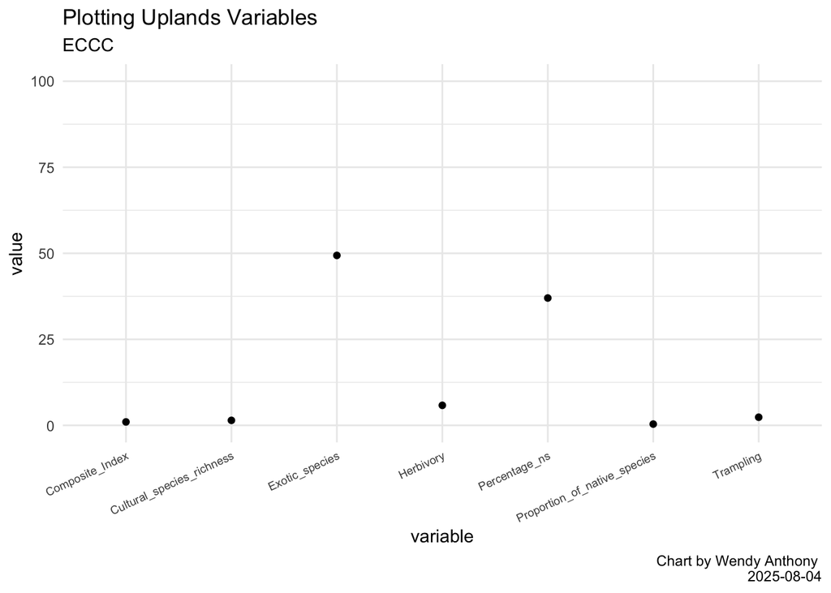

```r
Uplands_long_plot  <-  ggplot(Uplands_long,
                    aes(x = variable, y = value)) +
  # https://www.sthda.com/english/wiki/ggplot2-axis-scales-and-transformations
                    ylim(0, 100) +
                    geom_point() +
                    theme_minimal() + #get rid of grey background and tick marks
                    theme(legend.position="none") + #remove legend
                    theme(axis.text.x = element_text(angle = 25, vjust = 1, hjust=1, size = 7)) +
                    labs(title='Plotting Uplands Variables',
                      subtitle='ECCC',
                      caption = "Chart by Wendy Anthony \n 2025-08-04")
Uplands_long_plot
```

[figure not shown]

```r
Gonzales_long_plot  <-  ggplot(Gonzales_long,
                    aes(x = variable, y = value)) +
  # https://www.sthda.com/english/wiki/ggplot2-axis-scales-and-transformations
                    ylim(0, 100) +
                    geom_point() +
                    theme_minimal() + #get rid of grey background and tick marks
                    theme(legend.position="none") + #remove legend
                    theme(axis.text.x = element_text(angle = 25, vjust = 1, hjust=1, size = 7)) +
                    labs(title='Plotting Gonzales Variables',
                      subtitle='ECCC',
                      caption = "Chart by Wendy Anthony \n 2025-08-04")
Gonzales_long_plot
```

## 5.4 Point Plot Long Anniversary_Island_long

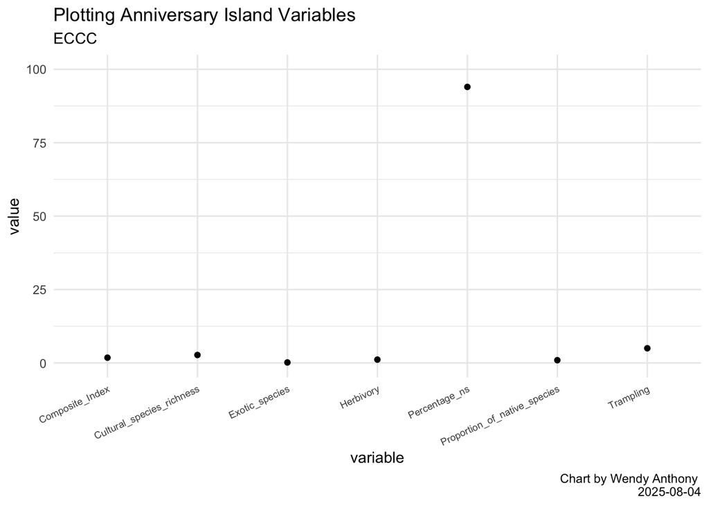

```r
Anniversary_Island_long_plot  <-  ggplot(Anniversary_Island_long,
                    aes(x = variable, y = value)) +
  # https://www.sthda.com/english/wiki/ggplot2-axis-scales-and-transformations
                    ylim(0, 100) +
                    geom_point() +
                    theme_minimal() + #get rid of grey background and tick marks
                    theme(legend.position="none") + #remove legend
                    theme(axis.text.x = element_text(angle = 25, vjust = 1, hjust=1, size = 7)) +
                    labs(title='Plotting Anniversary Island Variables',
                      subtitle='ECCC',
                      caption = "Chart by Wendy Anthony \n 2025-08-04")
Anniversary_Island_long_plot
```

### 5.4.1 Point Plot: Individual Site - Uplands Variables of Degradation

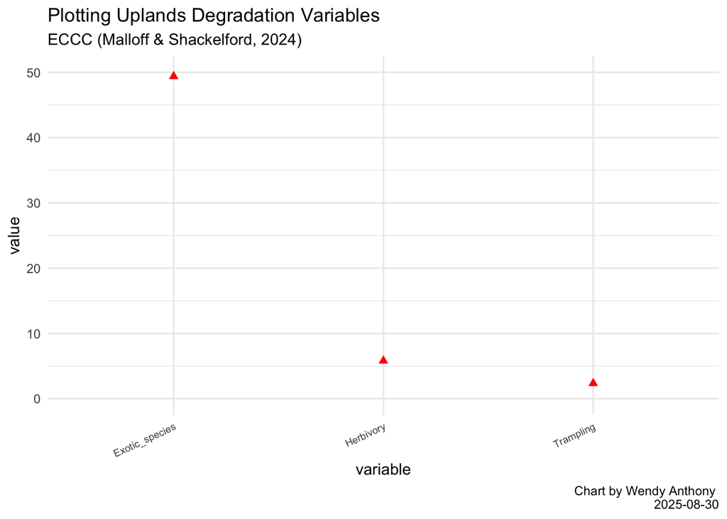

## 5.5 Bar Variables Compare Uplands

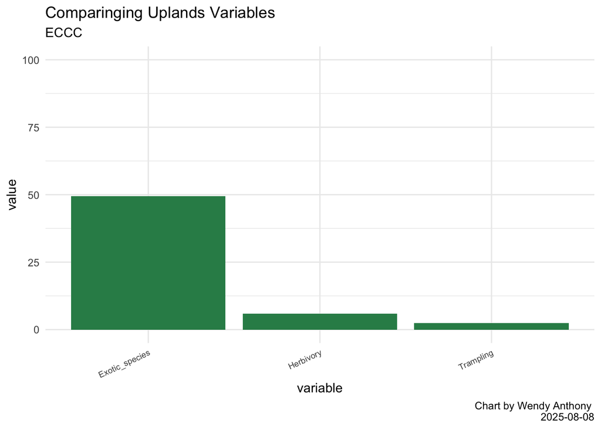

```r
compare_bar_uplands  <-  ggplot(Uplands_long,
                    aes(x = variable, y = value)) +

# Exotic_species
  # https://www.sthda.com/english/wiki/ggplot2-axis-scales-and-transformations
                    ylim(0, 100) +
                    geom_bar(stat = "identity", fill = "seagreen") +
                    theme_minimal() + #get rid of grey background and tick marks
                    theme(legend.position="none") + #remove legend
                    theme(axis.text.x = element_text(angle = 25, vjust = 1, hjust=1, size = 7)) +
                    labs(title='Comparinging Uplands Variables',
                      subtitle='ECCC',
                      caption = "Chart by Wendy Anthony \n 2025-08-08")
compare_bar_uplands
```

## 5.6 Compare Bar Variables multiple sites

```r
names(goe_eccc_1)
```

```
##  [1] "Subregion"                    "Site"
##  [3] "Proportion_of_native_species" "Cultural_species_richness"
##  [5] "Exotic_species"               "Trampling"
##  [7] "Herbivory"                    "Composite_Index"
##  [9] "Year"                         "Percentage_ns"
```

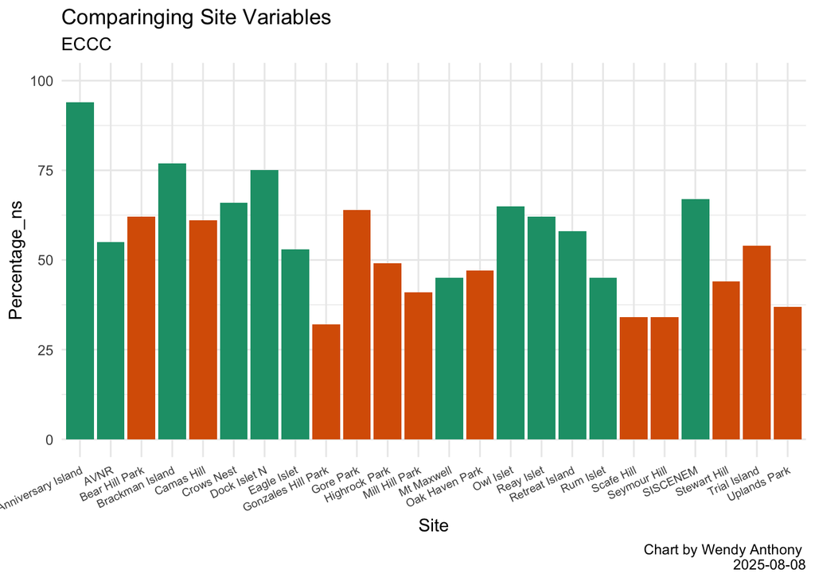

```r
compare_bar_multiple_sites  <-  ggplot(goe_eccc_1,
                    aes(x = Site, y = Percentage_ns, fill = Subregion)) +

# Exotic_species
  # https://www.sthda.com/english/wiki/ggplot2-axis-scales-and-transformations
                    ylim(0, 100) +
                    geom_bar(stat = "identity") +
  # Replace default palette of pink & blue
  scale_fill_brewer(palette = "Dark2") +
                    theme_minimal() + #get rid of grey background and tick marks
                    theme(legend.position="none") + #remove legend
                    theme(axis.text.x = element_text(angle = 25, vjust = 1, hjust=1, size = 7)) +
                    labs(title='Comparinging Site Variables',
                      subtitle='ECCC',
                      caption = "Chart by Wendy Anthony \n 2025-08-08")
compare_bar_multiple_sites
```

## 5.7 Arrange Compare Bar Variables multiple sites

```r
# https://r-graph-gallery.com/267-reorder-a-variable-in-ggplot2.html
names(goe_eccc_1)
```

```
##  [1] "Subregion"                    "Site"
##  [3] "Proportion_of_native_species" "Cultural_species_richness"
##  [5] "Exotic_species"               "Trampling"
##  [7] "Herbivory"                    "Composite_Index"
##  [9] "Year"                         "Percentage_ns"
```

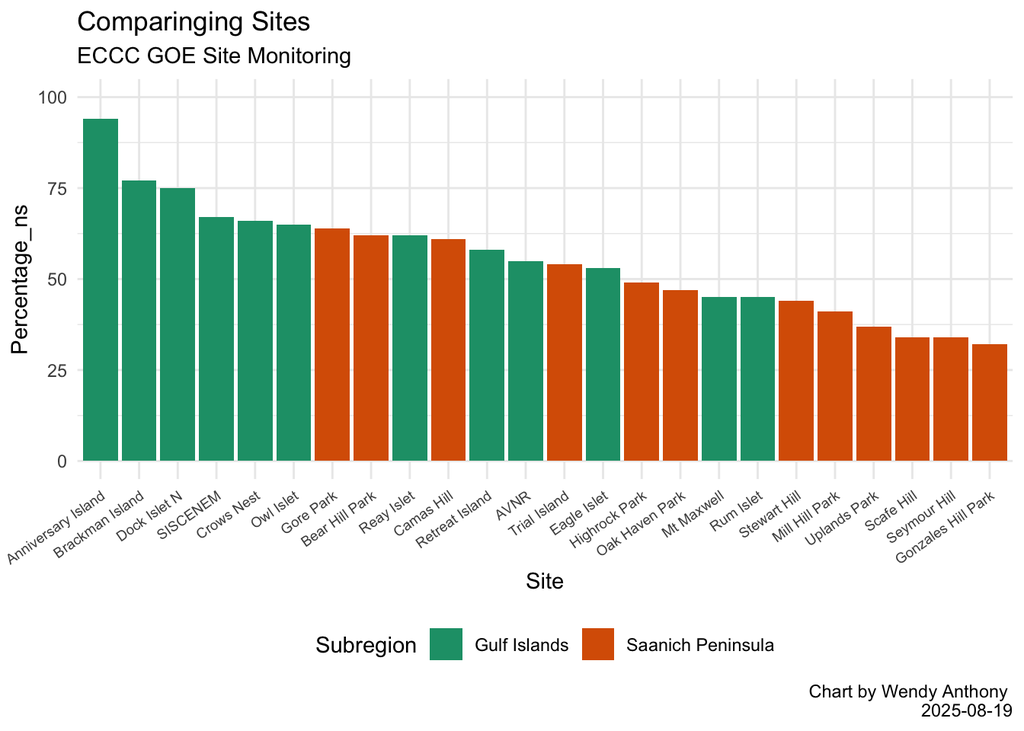

```r
# arrange values
#str(arr)
# goe_eccc_1 %>% arrange(Percentage_ns) -> arr
goe_eccc_1 %>% arrange(desc(Percentage_ns)) %>%
  # updates Site with new arrangement
   mutate(Site = factor(Site, levels = Site)) %>%
    ggplot(
      aes(x = Site, y = Percentage_ns, fill = Subregion)) +
  # https://www.sthda.com/english/wiki/ggplot2-axis-scales-and-transformations
                    ylim(0, 100) +
                    geom_bar(stat = "identity") +
  # Replace default palette of pink & blue
  scale_fill_brewer(palette = "Dark2") +
                    theme_minimal() + #get rid of grey background and tick marks
                    theme(legend.position="bottom") +
                    theme(axis.text.x = element_text(angle = 35, vjust = 1, hjust=1, size = 7)) +
                    labs(title='Comparinging Sites',
                      subtitle='ECCC GOE Site Monitoring',
                      caption = "Chart by Wendy Anthony \n 2025-08-19")
```

## 5.8 TEST Stacking Bar Variables multiple sites

```r
# https://r-graph-gallery.com/267-reorder-a-variable-in-ggplot2.html
# View(mpg)
# g <- ggplot(goe_eccc_1, aes(Subregion))
# p <-  g + geom_bar(aes(fill = Site))
# ggplotly(p)
#
# #https://stackoverflow.com/questions/6693257/making-a-stacked-bar-plot-for-multiple-variables-ggplot2-in-r
# dfr <- data.frame(
#   V1 = c(0.1, 0.2, 0.3),
#   V2 = c(0.2, 0.3, 0.2),
#   V3 = c(0.3, 0.6, 0.5),
#   V4 = c(0.5, 0.1, 0.7),
#   row.names = LETTERS[1:3]
# )
#
# goe_eccc_2 <- subset(goe_eccc_1, , -c(Subregion))
#
# goe_eccc_2 %>% rownames_to_column("ID") %>% pivot_longer(!ID) %>%
#   ggplot() +
#   geom_col(aes(x = ID, y = value, fill = name), position = 'fill')
# # Error in `pivot_longer_spec()`:
# #! Can't combine `Site` <character> and `Proportion_of_native_species` <double>.
#
# names(goe_eccc_1)
#     ggplot(goe_eccc_1,
#       aes(x = Site, y = Percentage_ns, fill = Subregion, color = Subregion)) +
#   # https://www.sthda.com/english/wiki/ggplot2-axis-scales-and-transformations
#                     ylim(0, 100) +
#                     geom_bar(stat = "identity") +
#                     theme_minimal() + #get rid of grey background and tick marks
#                     theme(legend.position="bottom") +
#                     theme(axis.text.x = element_text(angle = 35, vjust = 1, hjust=1, size = 7)) +
#                     labs(title='Comparinging Sites',
#                       subtitle='ECCC GOE Site Monitoring',
#                       caption = "Chart by Wendy Anthony \n 2025-08-19")
```

## 5.9 ??? NOTWORKING Compare Column Variables Uplands

```r
colnames(goe_eccc_1)
```

```
##  [1] "Subregion"                    "Site"
##  [3] "Proportion_of_native_species" "Cultural_species_richness"
##  [5] "Exotic_species"               "Trampling"
##  [7] "Herbivory"                    "Composite_Index"
##  [9] "Year"                         "Percentage_ns"
```

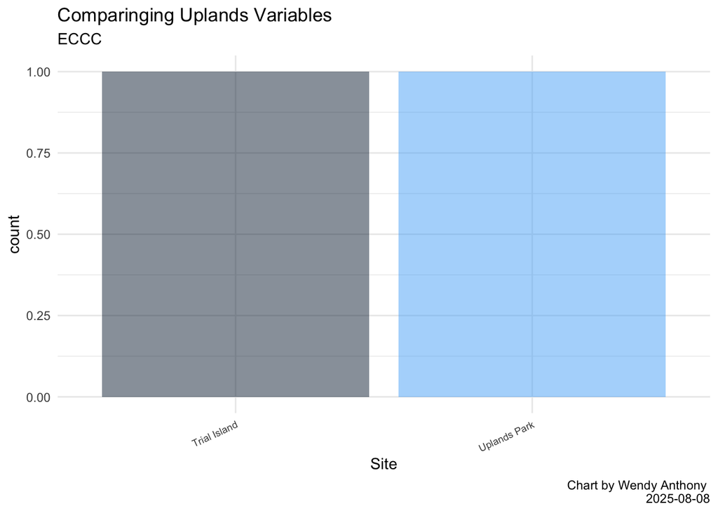

```r
goe_eccc_1_filter <- filter(goe_eccc_1, goe_eccc_1$Site %in% c("Uplands Park", "Trial Island"))


compare_col_uplands <- ggplot(goe_eccc_1_filter,
  aes(Site, fill = Exotic_species)) +
  geom_bar(position = "dodge", alpha = 0.5) +
                    theme_minimal() + #get rid of grey background and tick marks
                    theme(legend.position="none") + #remove legend
                    theme(axis.text.x = element_text(angle = 25, vjust = 1, hjust=1, size = 7)) +
                    labs(title='Comparinging Uplands Variables',
                      subtitle='ECCC',
                      caption = "Chart by Wendy Anthony \n 2025-08-08")
compare_col_uplands
```

# 6 TEST NOT WORKING Facet wraps

## 6.1 facet_wrap(~Subregion)

- need to filter Subregion for each ???

```r
names(goe_eccc_1)
```

```
##  [1] "Subregion"                    "Site"
##  [3] "Proportion_of_native_species" "Cultural_species_richness"
##  [5] "Exotic_species"               "Trampling"
##  [7] "Herbivory"                    "Composite_Index"
##  [9] "Year"                         "Percentage_ns"
```

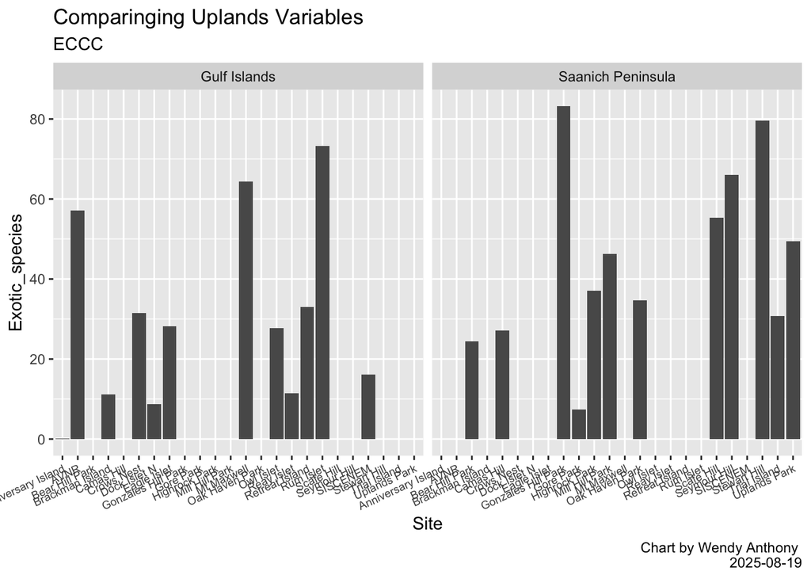

```r
ggplot(goe_eccc_1,
       aes(x = Site, y = Exotic_species)) +
  geom_col() +
  facet_wrap(~Subregion) +
  theme(legend.position="none") + #remove legend
   theme(axis.text.x = element_text(angle = 25, vjust = 1, hjust=1, size = 7)) +
   labs(title='Comparinging Uplands Variables',
      subtitle='ECCC',
      caption = "Chart by Wendy Anthony \n 2025-08-19")
```

## 6.2 ??? TEST FILTER SAME AS PREVIOUS NOT WORKINGfacet_wrap

- need to filter Subregion for each ???

```r
names(goe_eccc_1)
```

```
##  [1] "Subregion"                    "Site"
##  [3] "Proportion_of_native_species" "Cultural_species_richness"
##  [5] "Exotic_species"               "Trampling"
##  [7] "Herbivory"                    "Composite_Index"
##  [9] "Year"                         "Percentage_ns"
```

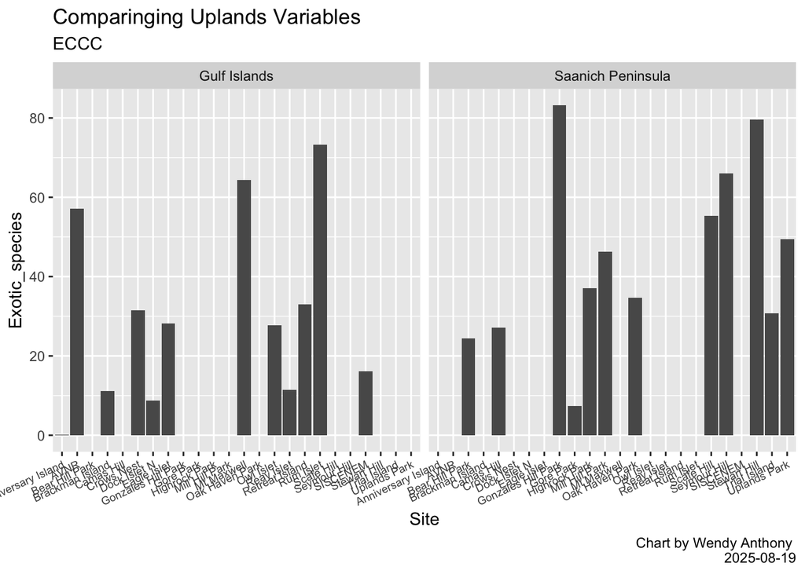

```r
ggplot(goe_eccc_1,
       aes(x = Site, y = Exotic_species)) +
  geom_col() +
  facet_wrap(~Subregion) +
  theme(legend.position="none") + #remove legend
   theme(axis.text.x = element_text(angle = 25, vjust = 1, hjust=1, size = 7)) +
   labs(title='Comparinging Uplands Variables',
      subtitle='ECCC',
      caption = "Chart by Wendy Anthony \n 2025-08-19")
```

# 7 Test GGplot Function

## 7.1 Violin Chart Function

```r
goe_eccc <- read.csv("data/SiteData-TEST-GOE-Monitor.csv", header = TRUE, sep = ",", stringsAsFactors=FALSE)
str(goe_eccc)
```

```
## 'data.frame':    24 obs. of  9 variables:
##  $ Subregion                   : chr  "Gulf Islands" "Gulf Islands" "Gulf Islands" "Gulf Islands" ...
##  $ Site                        : chr  "Anniversary Island" "AVNR" "Brackman Island" "Crows Nest" ...
##  $ Proportion_of_native_species: num  0.94 0.55 0.77 0.66 0.75 0.53 0.45 0.65 0.62 0.58 ...
##  $ Cultural_species_richness   : num  2.71 1.3 2.8 1.07 3.6 0.8 0.42 2 3.6 2.33 ...
##  $ Exotic_species              : num  0.17 57.19 11.17 31.51 8.8 ...
##  $ Trampling                   : num  5 4.7 5.4 1.64 12.2 ...
##  $ Herbivory                   : num  1.14 36.5 0 26.71 0.1 ...
##  $ Composite_Index             : num  1.8 0.6 2 1 1.6 0.8 0.2 1.4 1 1 ...
##  $ Year                        : int  2023 2023 2023 2023 2023 2023 2023 2023 2023 2023 ...
```

```r
names(goe_eccc)
```

```
## [1] "Subregion"                    "Site"
## [3] "Proportion_of_native_species" "Cultural_species_richness"
## [5] "Exotic_species"               "Trampling"
## [7] "Herbivory"                    "Composite_Index"
## [9] "Year"
```

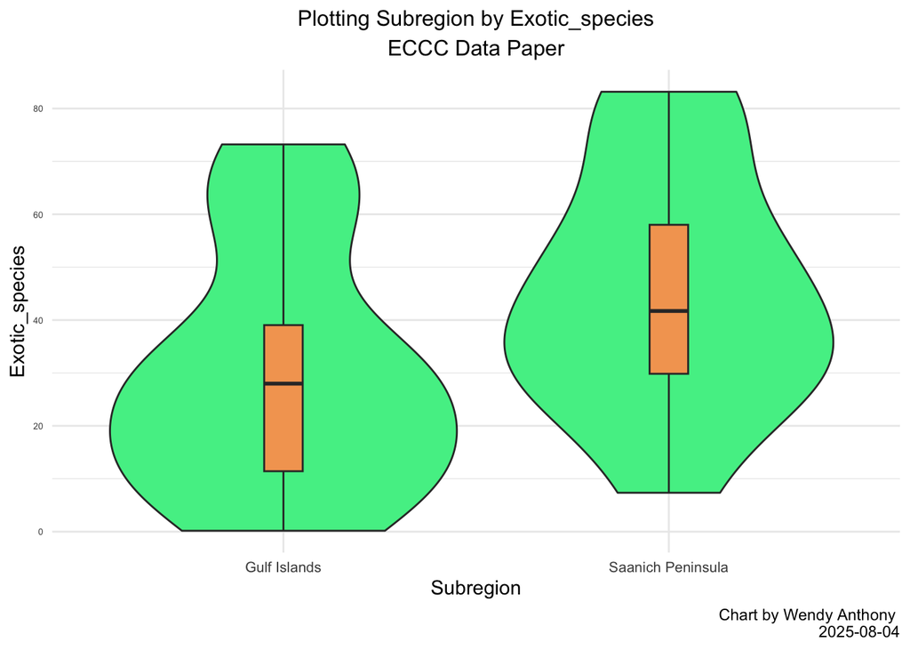

```r
subregion_var_violin <- function(file, title, subtitle, colx, coly, xlab, ylab, caption){

    ggplot2::ggplot(file,
        ggplot2::aes(x = colx, y = coly)) +
    ggplot2::geom_violin(fill = "seagreen2") +
    ggplot2::geom_boxplot(width = 0.1, fill = "sandybrown") +
    ggplot2::theme_minimal() + #get rid of grey background and tick marks
    ggplot2::theme(legend.position="none") + #remove legend
    ggplot2::theme(
      axis.text.x = ggplot2::element_text(vjust = 1, hjust = .5, size = 8),
      axis.text.y = ggplot2::element_text(size = 5),
      plot.title = ggplot2::element_text(hjust = 0.5, size = 12),
      plot.subtitle = ggplot2::element_text(hjust = 0.5, size = 12)) +
    #theme(axis.text.x = element_text(angle = 25, vjust = 1, hjust=1, size = 7)) +
    ggplot2::labs(title=title,
         subtitle=subtitle,
         caption = caption,
         x = xlab, y = ylab)
  #subregion_exsp

}

subregion_var_violin(goe_eccc, 'Plotting Subregion by Exotic_species', 'ECCC Data Paper', goe_eccc$Subregion, goe_eccc$Exotic_species, "Subregion", "Exotic_species", "Chart by Wendy Anthony \n 2025-08-04")
```

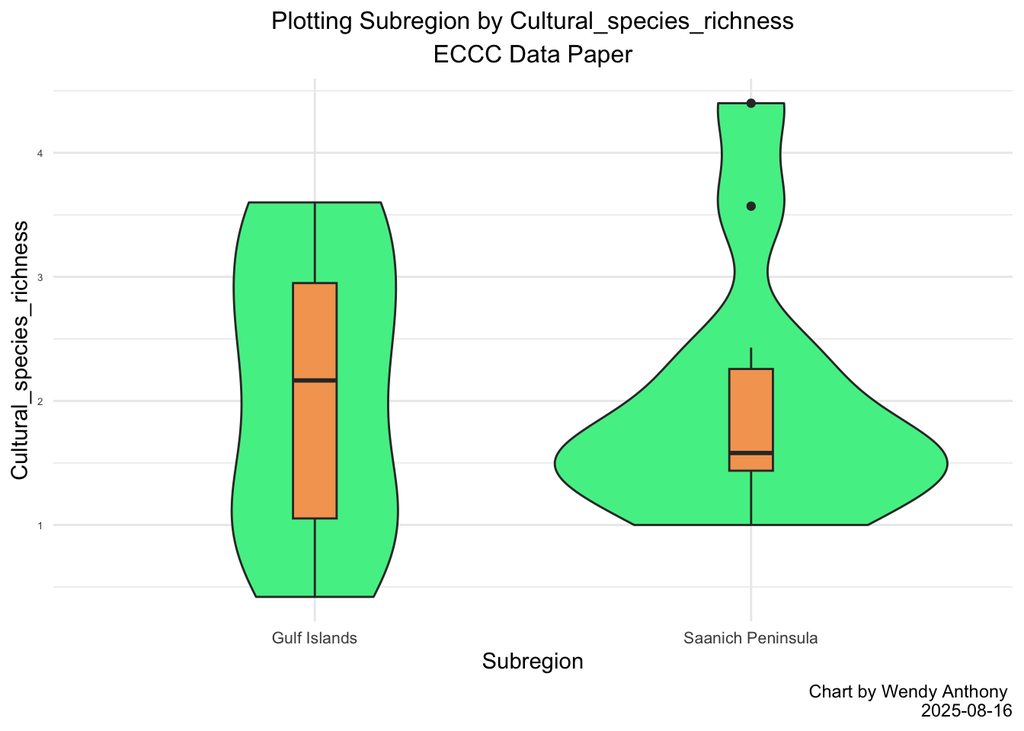

```r
subregion_var_violin(goe_eccc,'Plotting Subregion by Cultural_species_richness', 'ECCC Data Paper', goe_eccc$Subregion, goe_eccc$Cultural_species_richness, "Subregion", "Cultural_species_richness", "Chart by Wendy Anthony \n 2025-08-16")
```

## 7.2 Point Chart Function

### 7.2.1 ggplot point chart

```r
goe_eccc <- read.csv("data/SiteData-TEST-GOE-Monitor.csv", header = TRUE, sep = ",", stringsAsFactors=FALSE)

str(goe_eccc)
```

```
## 'data.frame':    24 obs. of  9 variables:
##  $ Subregion                   : chr  "Gulf Islands" "Gulf Islands" "Gulf Islands" "Gulf Islands" ...
##  $ Site                        : chr  "Anniversary Island" "AVNR" "Brackman Island" "Crows Nest" ...
##  $ Proportion_of_native_species: num  0.94 0.55 0.77 0.66 0.75 0.53 0.45 0.65 0.62 0.58 ...
##  $ Cultural_species_richness   : num  2.71 1.3 2.8 1.07 3.6 0.8 0.42 2 3.6 2.33 ...
##  $ Exotic_species              : num  0.17 57.19 11.17 31.51 8.8 ...
##  $ Trampling                   : num  5 4.7 5.4 1.64 12.2 ...
##  $ Herbivory                   : num  1.14 36.5 0 26.71 0.1 ...
##  $ Composite_Index             : num  1.8 0.6 2 1 1.6 0.8 0.2 1.4 1 1 ...
##  $ Year                        : int  2023 2023 2023 2023 2023 2023 2023 2023 2023 2023 ...
```

```r
names(goe_eccc)
```

```
## [1] "Subregion"                    "Site"
## [3] "Proportion_of_native_species" "Cultural_species_richness"
## [5] "Exotic_species"               "Trampling"
## [7] "Herbivory"                    "Composite_Index"
## [9] "Year"
```

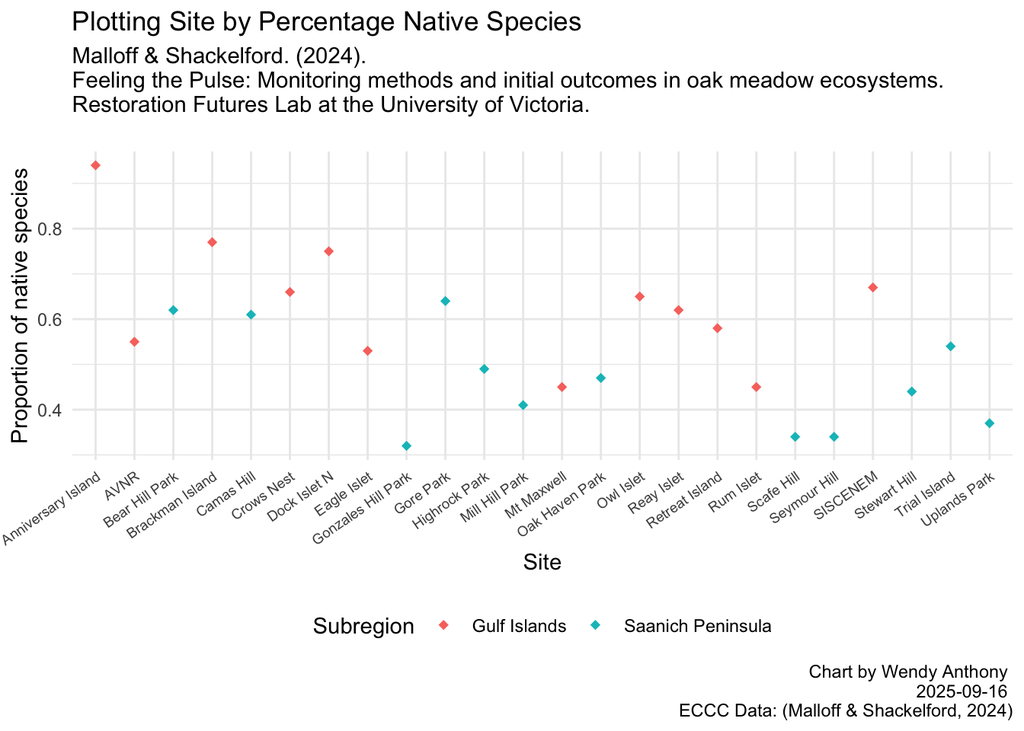

```r
subregion_var_point <- function(file, title, subtitle, colx, coly, xlab, ylab, caption){

ggplot(file,
                    aes(x = colx, y = coly, colour = Subregion)) +
                    geom_point(shape = 18, size = 2) +
    # Replace default palette of pink & blue
    scale_fill_brewer(palette = "Dark2") +
                    theme_minimal() + #get rid of grey background and tick marks
                    theme(legend.position="bottom") +
                    # theme(legend.position="none") + #remove legend
                    theme(axis.text.x = element_text(angle =35, vjust = 1, hjust=1, size = 7)) +
                    labs(title=title,
                      subtitle=subtitle,
                      caption = caption,
                      x = xlab, y = ylab)
}

subregion_var_point(goe_eccc,'Plotting Site by Percentage Native Species', 'Malloff & Shackelford. (2024). \nFeeling the Pulse: Monitoring methods and initial outcomes in oak meadow ecosystems. \nRestoration Futures Lab at the University of Victoria.
', goe_eccc$Site, goe_eccc$Proportion_of_native_species, "Site", "Proportion of native species", "Chart by Wendy Anthony \n 2025-09-16 \n ECCC Data: (Malloff & Shackelford, 2024)")
```

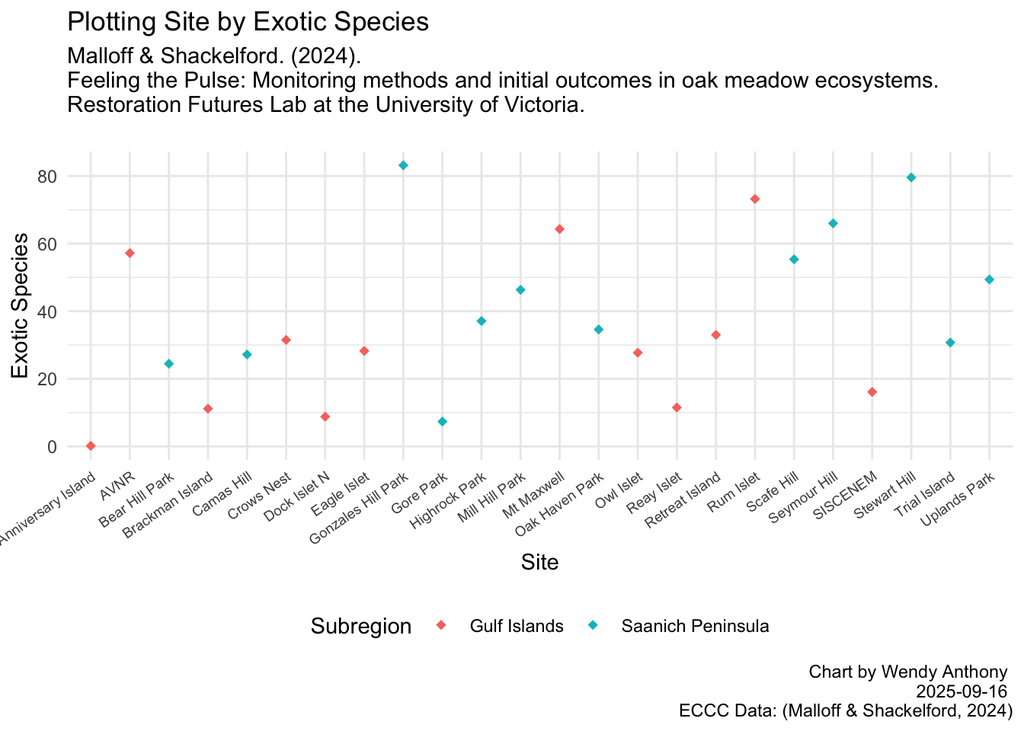

```r
subregion_var_point(goe_eccc,'Plotting Site by Exotic Species', 'Malloff & Shackelford. (2024). \nFeeling the Pulse: Monitoring methods and initial outcomes in oak meadow ecosystems. \nRestoration Futures Lab at the University of Victoria.
', goe_eccc$Site, goe_eccc$Exotic_species, "Site", "Exotic Species", "Chart by Wendy Anthony \n 2025-09-16 \n ECCC Data: (Malloff & Shackelford, 2024)")
```

### 7.2.2 plotly ggplot point chart

```r
goe_eccc <- read.csv("data/SiteData-TEST-GOE-Monitor.csv", header = TRUE, sep = ",", stringsAsFactors=FALSE)

str(goe_eccc)
```

```
## 'data.frame':    24 obs. of  9 variables:
##  $ Subregion                   : chr  "Gulf Islands" "Gulf Islands" "Gulf Islands" "Gulf Islands" ...
##  $ Site                        : chr  "Anniversary Island" "AVNR" "Brackman Island" "Crows Nest" ...
##  $ Proportion_of_native_species: num  0.94 0.55 0.77 0.66 0.75 0.53 0.45 0.65 0.62 0.58 ...
##  $ Cultural_species_richness   : num  2.71 1.3 2.8 1.07 3.6 0.8 0.42 2 3.6 2.33 ...
##  $ Exotic_species              : num  0.17 57.19 11.17 31.51 8.8 ...
##  $ Trampling                   : num  5 4.7 5.4 1.64 12.2 ...
##  $ Herbivory                   : num  1.14 36.5 0 26.71 0.1 ...
##  $ Composite_Index             : num  1.8 0.6 2 1 1.6 0.8 0.2 1.4 1 1 ...
##  $ Year                        : int  2023 2023 2023 2023 2023 2023 2023 2023 2023 2023 ...
```

```r
names(goe_eccc)
```

```
## [1] "Subregion"                    "Site"
## [3] "Proportion_of_native_species" "Cultural_species_richness"
## [5] "Exotic_species"               "Trampling"
## [7] "Herbivory"                    "Composite_Index"
## [9] "Year"
```

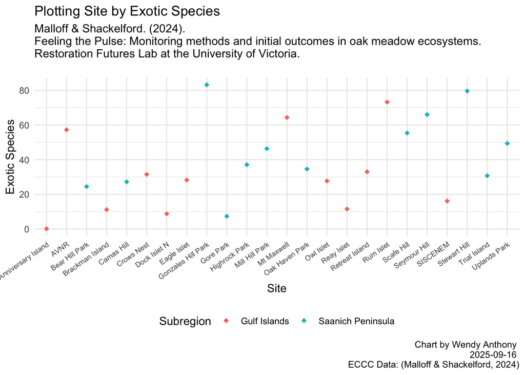

```r
subregion_var_point <- function(file, title, subtitle, colx, coly, xlab, ylab, caption){

ggplot(file,
                    aes(x = colx, y = coly, colour = Subregion)) +
                    geom_point(shape = 18, size = 2) +
    # Replace default palette of pink & blue
    scale_fill_brewer(palette = "Dark2") +
                    theme_minimal() + #get rid of grey background and tick marks
                    theme(legend.position="bottom") +
                    # theme(legend.position="none") + #remove legend
                    theme(axis.text.x = element_text(angle =35, vjust = 1, hjust=1, size = 7)) +
                    labs(title=title,
                      subtitle=subtitle,
                      caption = caption,
                      x = xlab, y = ylab)
}

p2 <- subregion_var_point(goe_eccc,'Plotting Site by Percentage Native Species', 'Malloff & Shackelford. (2024). \nFeeling the Pulse: Monitoring methods and initial outcomes in oak meadow ecosystems. \nRestoration Futures Lab at the University of Victoria.
', goe_eccc$Site, goe_eccc$Proportion_of_native_species, "Site", "Proportion of native species", "Chart by Wendy Anthony \n 2025-09-16 \n ECCC Data: (Malloff & Shackelford, 2024)")

subregion_var_point(goe_eccc,'Plotting Site by Exotic Species', 'Malloff & Shackelford. (2024). \nFeeling the Pulse: Monitoring methods and initial outcomes in oak meadow ecosystems. \nRestoration Futures Lab at the University of Victoria.
', goe_eccc$Site, goe_eccc$Exotic_species, "Site", "Exotic Species", "Chart by Wendy Anthony \n 2025-09-16 \n ECCC Data: (Malloff & Shackelford, 2024)")
```

```r
ggplotly(p2)
```

[interactive chart not shown]

# 8 Leaflet Map

## 8.1 Custom Icons

```r
Sites_eccc <- read.csv("data/SiteDetails-TEST-GOE-Monitor.csv", header = TRUE, sep = ",")

names(Sites_eccc)
```

```
## [1] "Subregion"             "Site"                  "Land.Manager"
## [4] "Main.Restoration.Type" "Restoration.Intensity" "Area.ha"
## [7] "Lat"                   "Lng"
```

```r
library(dplyr)
library(leaflet)
library(htmlwidgets) # for responsive web map

# custom icon
# https://leafletjs.com/examples/custom-icons/
greenLeafIcon <- makeIcon(
  iconUrl = "https://leafletjs.com/examples/custom-icons/leaf-green.png",
  iconWidth = 38, iconHeight = 95,
  iconAnchorX = 22, iconAnchorY = 94,
  shadowUrl = "https://leafletjs.com/examples/custom-icons/leaf-shadow.png",
  shadowWidth = 50, shadowHeight = 64,
  shadowAnchorX = 4, shadowAnchorY = 62
)
# change LeafIcon size 1/2
greenLeafIconSm <- makeIcon(
  iconUrl = "https://leafletjs.com/examples/custom-icons/leaf-green.png",
  iconWidth = 19, iconHeight = 47,
  iconAnchorX = 11, iconAnchorY = 47,
  shadowUrl = "https://leafletjs.com/examples/custom-icons/leaf-shadow.png",
  shadowWidth = 25, shadowHeight = 32,
  shadowAnchorX = 2, shadowAnchorY = 31
)

# Title control
title <- tags$div(HTML('<b>ECC Site Maps</b><br>Malloff & Shackelford. (2024). Feeling the Pulse: Monitoring methods and initial outcomes in oak meadow ecosystems. Restoration Futures Lab at the University of Victoria'))


ECCC_map <- leaflet(Sites_eccc) %>%
  addProviderTiles("Esri.WorldImagery") %>%
  addMarkers(
             ~ Lng, ~ Lat, icon = greenLeafIconSm,
             popup = paste0("<b>Subregion:</b> ", Sites_eccc$Subregion, "<br>", "<b>Site:</b> ", Sites_eccc$Site, "<br>", "<b>Latitude:</b> ", Sites_eccc$Lat, "<br>", "<b>Longitude:</b> ", Sites_eccc$Lng,  "<br><br>", "<b>Land Manager:</b> ", Sites_eccc$Land.Manager, "<br>", "<b>Main Restoration:</b> ", Sites_eccc$Main.Restoration.Type, "<br>", "<b>Restoration Intensity:</b> ", Sites_eccc$Restoration.Intensity, "<br>", "<b> Area:</b> ", Sites_eccc$Area.ha, " ha")) %>%
  setView(-123.44799, 48.64919, 9) %>%
  addMiniMap(width = 150, height = 150, zoomLevelOffset = -4) %>%
  addControl(title, position = "topright")

# Display map
ECCC_map
```

[interactive chart not shown]

```r
# Save map
saveWidget(ECCC_map, "output/ECCC_map_custom_icons.html")
```

## 8.2 Circle Markers

```r
# NOT WORKING - Sites not same
#goe_eccc_sites <- cbind(goe_eccc, Sites_eccc)
# try to add , "<br>",  "<b>Composite Index:</b> ", goe_eccc_sites$Composite_Index
# names(goe_eccc_sites)
names(Sites_eccc)
```

```
## [1] "Subregion"             "Site"                  "Land.Manager"
## [4] "Main.Restoration.Type" "Restoration.Intensity" "Area.ha"
## [7] "Lat"                   "Lng"
```

```r
library(dplyr)
library(leaflet)
library(htmlwidgets) # for responsive web map


# Title control
title <- tags$div(HTML('<b>ECC Site Maps</b><br>Malloff & Shackelford. (2024). Feeling the Pulse: Monitoring methods and initial outcomes in oak meadow ecosystems. Restoration Futures Lab at the University of Victoria'))

# https://rstudio.github.io/leaflet/articles/markers.html
# Create a palette that maps factor levels to colors
pal <- colorFactor(c("green", "orange"), domain = c("Saanich Peninsula", "Gulf Islands"))

ECCC_map <- leaflet(Sites_eccc) %>%
  addProviderTiles("Esri.WorldImagery") %>%
  addCircleMarkers(
             ~ Lng, ~ Lat, radius = ~ifelse(Subregion == "Saanich Peninsula", 4, 5),
    color = ~pal(Subregion),
    stroke = FALSE, fillOpacity = 0.5,
             popup = paste0("<b>Site:</b> ", Sites_eccc$Site, "<br>", "<b>Subregion:</b> ", Sites_eccc$Subregion, "<br>", "<b>Latitude:</b> ", Sites_eccc$Lat, "<br>", "<b>Longitude:</b> ", Sites_eccc$Lng,  "<br><br>", "<b>Land Manager:</b> ", Sites_eccc$Land.Manager, "<br>", "<b>Main Restoration:</b> ", Sites_eccc$Main.Restoration.Type, "<br>", "<b>Restoration Intensity:</b> ", Sites_eccc$Restoration.Intensity, "<br>", "<b> Area:</b> ", Sites_eccc$Area.ha, " ha")) %>%
  setView(-123.44799, 48.64919, 9) %>%
  addMiniMap(width = 150, height = 150, zoomLevelOffset = -4) %>%
  addControl(title, position = "topright")

# Display map
ECCC_map
```

[interactive chart not shown]

```r
# Save map
saveWidget(ECCC_map, "output/ECCC_map_circle_markers.html")
```

```r
names(Sites_eccc)
```

```
## [1] "Subregion"             "Site"                  "Land.Manager"
## [4] "Main.Restoration.Type" "Restoration.Intensity" "Area.ha"
## [7] "Lat"                   "Lng"
```

```r
library(dplyr)
library(leaflet)
library(htmlwidgets) # for responsive web map


# Title control
# Malloff & Shackelford. (2024). Feeling the Pulse: Monitoring methods and initial outcomes in oak meadow ecosystems. Restoration Futures Lab at the University of Victoria
title <- tags$div(HTML('<p style="font-size:12px;font-weight:bold">ECC Sites Map</p>'))

# https://rstudio.github.io/leaflet/articles/markers.html
# Create a palette that maps factor levels to colors
pal <- colorFactor(c("green", "orange"), domain = c("Saanich Peninsula", "Gulf Islands"))

ECCC_map <- leaflet(Sites_eccc) %>%
  addProviderTiles("Esri.WorldImagery") %>%
  addCircleMarkers(
             ~ Lng, ~ Lat,
# https://stackoverflow.com/questions/40137212/variable-marker-size-feature-in-leaflet-r
              radius = ~goe_eccc$Composite_Index * 3,
              # radius = ~Sites_eccc$Area.ha,
                  # radius = ~sqrt(Sites_eccc$Area.ha),
 # size smaller is Saanich, else larger if Gulf
#             radius = ~ifelse(Subregion == "Saanich Peninsula", 4, 5),
    color = ~pal(Subregion),
    stroke = FALSE, fillOpacity = 0.5,
             popup = paste0("<b>Site:</b> ", Sites_eccc$Site, "<br>", "<b>Subregion:</b> ", Sites_eccc$Subregion, "<br>", "<b>Latitude:</b> ", Sites_eccc$Lat, "<br>", "<b>Longitude:</b> ", Sites_eccc$Lng,  "<br><br>", "<b>Land Manager:</b> ", Sites_eccc$Land.Manager, "<br>", "<b>Main Restoration:</b> ", Sites_eccc$Main.Restoration.Type, "<br>", "<b>Restoration Intensity:</b> ", Sites_eccc$Restoration.Intensity, "<br>", "<b> Area:</b> ", Sites_eccc$Area.ha, " ha")) %>%
  setView(-123.44799, 48.64919, 9) %>%
  addMiniMap(width = 150, height = 150, zoomLevelOffset = -4) %>%
  addControl(title, position = "topright")

# Display map
ECCC_map
```

[interactive chart not shown]

```r
# Save map
saveWidget(ECCC_map, "output/ECCC_map_area.html")
```

## 8.4 Circle Markers Sized to Composite_Index

goe_eccc_all_site_data.csv

```r
goe_eccc_sites_1 <- read.csv("data/goe_eccc_all_site_data.csv")
names(goe_eccc_sites_1)
```

```
##  [1] "Subregion"                    "Site"
##  [3] "Land_Manager"                 "Main_Restoration_Type"
##  [5] "Restoration_Intensity"        "Area_ha"
##  [7] "Lat"                          "Lng"
##  [9] "Proportion_of_native_species" "Cultural_species_richness"
## [11] "Exotic_species"               "Trampling"
## [13] "Herbivory"                    "Composite_Index"
## [15] "Year"                         "Percentage_ns"
```

```r
library(dplyr)
library(leaflet)
library(htmlwidgets) # for responsive web map


# Title control
# Malloff & Shackelford. (2024). Feeling the Pulse: Monitoring methods and initial outcomes in oak meadow ecosystems. Restoration Futures Lab at the University of Victoria
title <- tags$div(HTML('<p style="font-size:12px;font-weight:bold">ECC Sites Map</p>'))

# https://rstudio.github.io/leaflet/articles/markers.html
# Create a palette that maps factor levels to colors
pal <- colorFactor(c("#d7191c", "#2c7bb6"), domain = c("Saanich Peninsula", "Gulf Islands"))

ECCC_map_1 <- leaflet(goe_eccc_sites_1) %>%
  addProviderTiles("Esri.WorldImagery") %>%
  addCircleMarkers(
             ~ Lng, ~ Lat,
# https://stackoverflow.com/questions/40137212/variable-marker-size-feature-in-leaflet-r
              radius = ~goe_eccc_sites_1$Composite_Index * 5,
              # radius = ~goe_eccc_sites_1$Area.ha,
                  # radius = ~sqrt(goe_eccc_sites_1$Area.ha),
 # size smaller is Saanich, else larger if Gulf
#             radius = ~ifelse(Subregion == "Saanich Peninsula", 4, 5),
    fillColor = ~pal(Subregion),
    color = "black",
    weight = 3, # size of circle border
    stroke = TRUE, fillOpacity = 0.5,
             popup = paste0("<b>Site:</b> ", "<b>", "<b>", goe_eccc_sites_1$Site, "</b>", "</b>", "<br><br>", "<b>Subregion:</b> ", goe_eccc_sites_1$Subregion, "<br>",
                        "<b>Latitude:</b> ", goe_eccc_sites_1$Lat, "<br>", "<b>Longitude:</b> ", goe_eccc_sites_1$Lng,  "<br><br>",
                        "<b>Land Manager:</b> ", goe_eccc_sites_1$Land_Manager, "<br>",
                        "<b>Main Restoration:</b> ", goe_eccc_sites_1$Main_Restoration_Type, "<br>",
                        "<b>Restoration Intensity:</b> ", goe_eccc_sites_1$Restoration_Intensity, "<br>",
                        "<b> Area:</b> ", goe_eccc_sites_1$Area_ha, " ha",
                        "<br><br>",
                        "<b>Proportion of native species:</b> ", goe_eccc_sites_1$Proportion_of_native_species, "<br>",
                        "<b>Cultural species richness:</b> ", goe_eccc_sites_1$Cultural_species_richness, "<br>",
                        "<b>Exotic species:</b> ", goe_eccc_sites_1$Exotic_species, "<br>",
                        "<b>Trampling:</b> ", goe_eccc_sites_1$Trampling, "<br>",
                        "<b>Herbivory:</b> ", goe_eccc_sites_1$Herbivory, "<br>",
                        "<b>Composite Index:</b> ", goe_eccc_sites_1$Composite_Index, "<br>")) %>%
  setView(-123.44799, 48.64919, 10) %>%
  addMiniMap(width = 150, height = 150, zoomLevelOffset = -4) %>%
  addControl(title, position = "topright")

# Display map
ECCC_map_1
```

[interactive chart not shown]

```r
# Save map
saveWidget(ECCC_map_1, "output/ECCC_map_CI.html")
```

## 8.5 Circle Markers Sized to Radius

### 8.5.1 Title code

goe_eccc_all_site_data.csv

```r
goe_eccc_sites_1 <- read.csv("data/goe_eccc_all_site_data.csv")
names(goe_eccc_sites_1)
```

```
##  [1] "Subregion"                    "Site"
##  [3] "Land_Manager"                 "Main_Restoration_Type"
##  [5] "Restoration_Intensity"        "Area_ha"
##  [7] "Lat"                          "Lng"
##  [9] "Proportion_of_native_species" "Cultural_species_richness"
## [11] "Exotic_species"               "Trampling"
## [13] "Herbivory"                    "Composite_Index"
## [15] "Year"                         "Percentage_ns"
```

```r
library(dplyr)
library(leaflet)
library(htmlwidgets) # for responsive web map


# Title control
# Malloff & Shackelford. (2024). Feeling the Pulse: Monitoring methods and initial outcomes in oak meadow ecosystems. Restoration Futures Lab at the University of Victoria
title <- '<p style="text-align: center; height: 30px; ">
<span style="font-size:10px;font-weight:bold; background-color: rgba(255, 255, 255, 0.9;");>ECCC GOE 2023 Monitoring Sites</span><br>
<span style="font-size:8px;font-style:italic; background-color: rgba(255, 255, 255, 0.9;">(Malloff & Shackelford, 2024)</span></p>'

# https://rstudio.github.io/leaflet/articles/markers.html
# Create a palette that maps factor levels to colors
pal <- colorFactor(c("#d7191c", "#2c7bb6"), domain = c("Saanich Peninsula", "Gulf Islands"))

ECCC_map_2 <- leaflet(goe_eccc_sites_1) %>%
  addProviderTiles("Esri.WorldImagery") %>%
  addCircleMarkers(
             ~ Lng, ~ Lat,
# https://stackoverflow.com/questions/40137212/variable-marker-size-feature-in-leaflet-r
#              radius = ~goe_eccc_sites_1$Composite_Index * 5,
              # radius = ~goe_eccc_sites_1$Area.ha,
                  # radius = ~sqrt(goe_eccc_sites_1$Area.ha),
 # size smaller is Saanich, else larger if Gulf
             radius = ~ifelse(Subregion == "Saanich Peninsula", 8, 8),
    fillColor = ~pal(Subregion),
    color = "black",
    weight = 3, # size of circle border
    stroke = TRUE, fillOpacity = 0.5,
             popup = paste0("<b>ECCC GOE 2023 Monitoring Data</b>", "<br>", "<i>(Malloff & Shackelford, 2024)</i>", "<br><br>",
               "<b>Site:</b> ", "<b>", goe_eccc_sites_1$Site, "</b>", "</b>", "<br><br>", "<b>Subregion:</b> ", goe_eccc_sites_1$Subregion, "<br>",
                        "<b>Latitude:</b> ", goe_eccc_sites_1$Lat, "<br>", "<b>Longitude:</b> ", goe_eccc_sites_1$Lng,  "<br><br>",
                        "<b>Land Manager:</b> ", goe_eccc_sites_1$Land_Manager, "<br>",
                        "<b>Main Restoration:</b> ", goe_eccc_sites_1$Main_Restoration_Type, "<br>",
                        "<b>Restoration Intensity:</b> ", goe_eccc_sites_1$Restoration_Intensity, "<br>",
                        "<b> Area:</b> ", goe_eccc_sites_1$Area_ha, " ha",
                        "<br><br>",
                        "<b>Proportion of native species:</b> ", goe_eccc_sites_1$Proportion_of_native_species, "<br>",
                        "<b>Cultural species richness:</b> ", goe_eccc_sites_1$Cultural_species_richness, "<br>",
                        "<b>Exotic species:</b> ", goe_eccc_sites_1$Exotic_species, "<br>",
                        "<b>Trampling:</b> ", goe_eccc_sites_1$Trampling, "<br>",
                        "<b>Herbivory:</b> ", goe_eccc_sites_1$Herbivory, "<br>",
                        "<b>Composite Index:</b> ", goe_eccc_sites_1$Composite_Index, "<br>")) %>%
  setView(-123.44799, 48.64919, 10) %>%
  # add controls
  addMiniMap(width = 150, height = 150, zoomLevelOffset = -4) %>%
  addControl(title, position = "topright")

# Display map
ECCC_map_2
```

[interactive chart not shown]

```r
# Save map
saveWidget(ECCC_map_2, "output/ECCC_map_radius-1.html")
```

# 9 Mermaid Methods Flow Chart

## 9.1 Flow for ER390 Monitoring Data

```r
DiagrammeR("
sequenceDiagram;
   Wendy->>HAT: ask for data;
   database->>HAT: monitoring data;
   database->>RStudio: upload and filter data;
   RStudio->>HAT: Report;
   HAT->>Wendy: data;
   alt monitoring data available
     RestorationTech->>database: upload data;
     RestorationTech->>Site: monitor;
     Site->>database: Site Monitoring Data;
     RStudio->>database: query data;
     Wendy->>RStudio: create data viz code;
   else data unavailable
     database->>RestorationTech: data not available;
     RestorationTech->>Site: remonitor;
     RestorationTech->>SiteCommunity: ask to remonitor;
     SiteCommunity->>RestorationTech: OK to remonitor;
   end
")
```

[interactive chart not shown]

## 9.2 Graph for ER390 Proposal Methods Workflow

[interactive chart not shown]

## 9.3 Workflow Graph

[interactive chart not shown]

## 9.4 Examples

### 9.4.1 Example graph

```r
DiagrammeR("
graph TB
 A-->B
 A-->C
 C-->E
 B-->D
 C-->D
 D-->F
 E-->F
")
```

[interactive chart not shown]

### 9.4.2 example Diagrammer shapes

[interactive chart not shown]

### 9.4.3 example Mermaid shapes

```r
mermaid("
        graph BT
        A((Salinity))
        A-->B(Barnacles)
        B-.->|-0.10|B1{Mussels}
        A-- 0.30 -->B1

        C[Air Temp]
        C-->B
        C-.->E(Macroalgae)
        E-->B1
        C== 0.89 ==>B1

        style A fill:#FFF, stroke:#333, stroke-width:4px
        style B fill:#9AA, stroke:#9AA, stroke-width:2px
        style B1 fill:#879, stroke:#333, stroke-width:1px
        style C fill:#ADF, stroke:#333, stroke-width:2px
        style E fill:#9C2, stroke:#9C2, stroke-width:2px

        ")
```

[interactive chart not shown]

### 9.4.4 Example sequenceDiagram

```r
  DiagrammeR("
sequenceDiagram;
   customer->>ticket seller: ask for a ticket;
   ticket seller->>database: seats;
   alt tickets available
     database->>ticket seller: ok;
     ticket seller->>customer: confirm;
     customer->>ticket seller: ok;
     ticket seller->>database: book a seat;
     ticket seller->>printer: print a ticket;
   else sold out
     database->>ticket seller: none left;
     ticket seller->>customer: sorry;
   end
")
```

[interactive chart not shown]

## 9.5 Gantt Charts for Timelines

### 9.5.1 Style Gantt code chunk

- supposed to widen Gantt chart, but doesn’t

### Gantt Chart ER390

```r
mermaid("
gantt
dateFormat  YYYY-MM-DD
title ER390 HAT Data Viz Project Timeline

section ER390 Project
  Nancy suggested Topic          :crit, done, first_7, 2025-07-22, 2025-07-23
  Talked to Vanessa at HAT       :crit, done, first_8, 2025-08-27,  2025-08-28
  Writing Proposal               :crit, active, first_9, 2025-08-27, 5d
  Start Project                        :active, first_10, 2025-09-03, 356d

section Important Things
  Applied For RNS Program         :crit, done, 2025-08-21, 24h
  Created Gantt Chart             :active, 2025-08-31, 24h

section Basic Tasks
  Creating RMarkdown code    :done, a1, 2025-08-04, 2025-08-31
  Writing Proposal            :active, after a1, 2025-08-31, 3d
  Email Nancy-RNS & Vanessa-HAT :active, 2025-09-02

section Shiny App
  Created Shiny App             :done, first_1, 2025-08-18, 2025-08-28
  Refining Shiny App            :active, first_5, 2025-08-18, 130d
  Interactive Data Table        :done, 2025-08-18, 2025-08-19

section RMarkdown
  Created Test Document         :done, first_6, 2025-08-04, 2025-08-05

section Shiny Clone
  Create Shiny Clone            :active, first_11, 2025-09-30, 150d

section Data Collection
  Collecting Example Data       :done, first_2, 2025-08-04, 10d
  Finish Collecting Data        : first_3, after first_2, 5d
  Do this after that            : first_4, after first_3, 5d

section Critical Tasks
  Completed, critical task      :done, done, import_1, 2025-08-18, 24h
  Also done, also critical      :active, done, import_2, after import_1, 2d
  Doing this important task now :active, active, import_3, after import_2, 3d
  Next critical task            :active, import_4, after import_3, 5d


section Interactive Data Viz
  First extras                  : extras_1, after import_4, 3d
  Second helping                : extras_2, after extras_1, 20h
  More of the extras            : extras_3, after extras_1, 48h

section The Extras
  Customize colours for HAT     :  2025-10-01, 2025-12-15
  Create R Package for HAT      :  2026-01-31, 2026-04-30


")
```

[interactive chart not shown]

### 9.5.2 Gantt ER390 dataframe

```r
ER390_gantt <- read.csv("data/ER390-Gantt-Tasks.csv", header = TRUE, sep = ",")

library(tidyr)
library(dplyr)
library(DiagrammeR)

mermaid(
  paste0(
    # mermaid "header", each component separated with "\n" (line break)
    "gantt", "\n",
    "dateFormat  YYYY-MM-DD", "\n",
    "title ER390 HAT Data Viz Project Timeline", "\n",
    # unite the first two columns (task & status) and separate them with ":"
    # then, unite the other columns and separate them with ","
    # this will create the required mermaid "body"
    paste(ER390_gantt %>%
            unite(i, task, status, sep = ":") %>%
            unite(j, i, pos, start, end, sep = ",") %>%
            .$j,
          collapse = "\n"
    ), "\n"
  )
)
```

[interactive chart not shown]

### 9.5.3 Gantt ggplot 1

```r
library(reshape2)
```

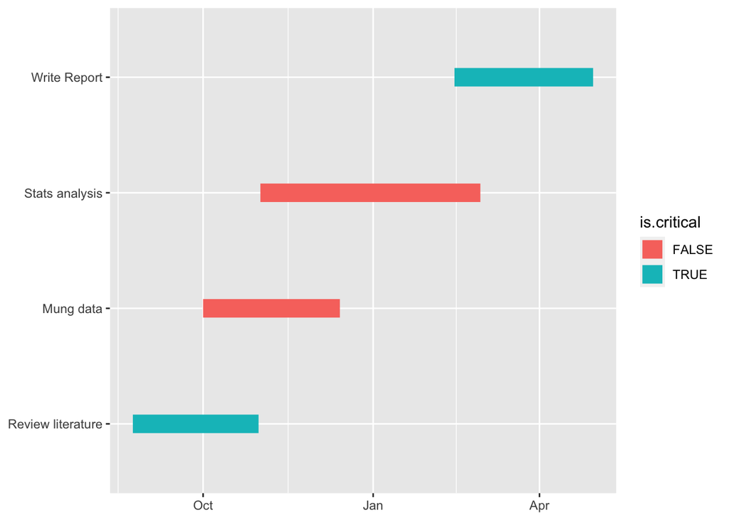

```r
library(ggplot2)

tasks <- c("Review literature", "Mung data", "Stats analysis", "Write Report")
dfr <- data.frame(
  name        = factor(tasks, levels = tasks),
  start.date  = as.Date(c("2010-08-24", "2010-10-01", "2010-11-01", "2011-02-14")),
  end.date    = as.Date(c("2010-10-31", "2010-12-14", "2011-02-28", "2011-04-30")),
  is.critical = c(TRUE, FALSE, FALSE, TRUE)
)
mdfr <- melt(dfr, measure.vars = c("start.date", "end.date"))

gantt_ggplot <- ggplot(mdfr, aes(value, name, colour = is.critical)) +
  # Warning: Using `size` aesthetic for lines was deprecated in ggplot2 3.4.0.
  geom_line(linewidth = 6) +
  xlab(NULL) +
  ylab(NULL)
gantt_ggplot
```

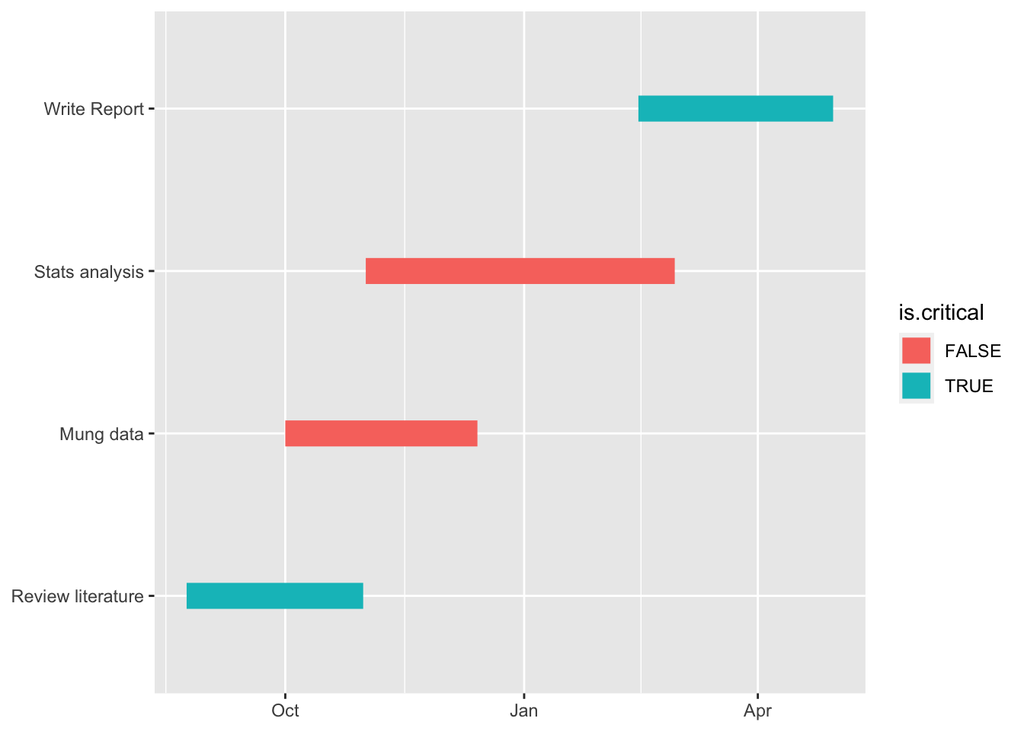

```r
# https://stackoverflow.com/questions/3550341/gantt-charts-with-r

tasks <- c("Review literature", "Mung data", "Stats analysis", "Write Report")
dfr <- data.frame(
  name        = factor(tasks, levels = tasks),
  start.date  = as.Date(c("2010-08-24", "2010-10-01", "2010-11-01", "2011-02-14")),
  end.date    = as.Date(c("2010-10-31", "2010-12-14", "2011-02-28", "2011-04-30")),
  is.critical = c(TRUE, FALSE, FALSE, TRUE)
)

ggplot(dfr, aes(x =start.date, xend= end.date, y=name, yend = name, color=is.critical)) +
  geom_segment(size = 6) +
  xlab(NULL) + ylab(NULL)
```

### 9.5.4 Gantt ggplot 2

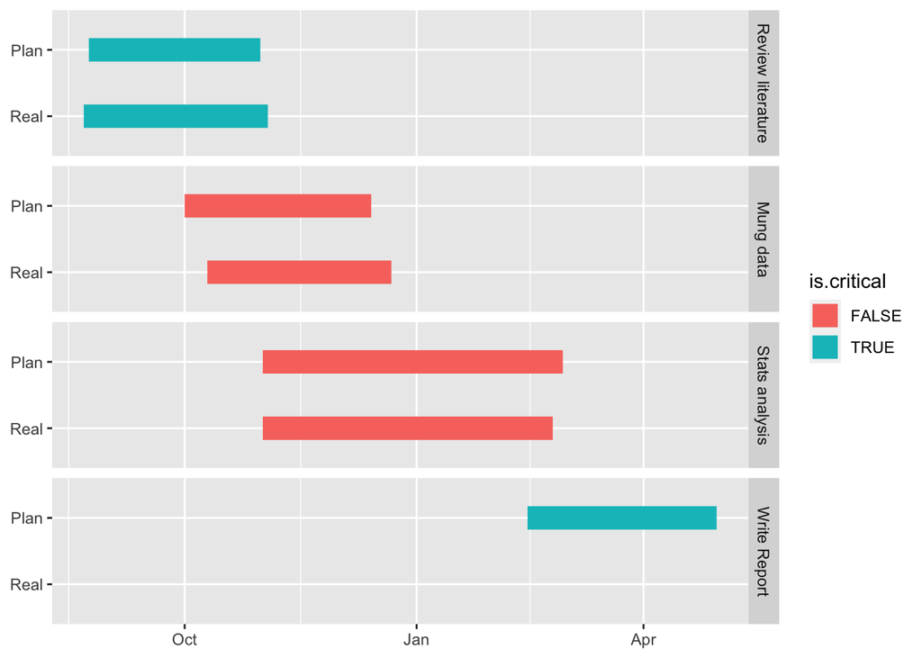

```r
library(reshape2)
tasks <- c("Review literature", "Mung data", "Stats analysis", "Write Report")
dfrP <- data.frame(
  name        = factor(tasks, levels = tasks),
  start.date  = as.Date(c("2010-08-24", "2010-10-01", "2010-11-01", "2011-02-14")),
  end.date    = as.Date(c("2010-10-31", "2010-12-14", "2011-02-28", "2011-04-30")),
  is.critical = c(TRUE, FALSE, FALSE, TRUE)
)
dfrR <- data.frame(
  name        = factor(tasks, levels = tasks),
  start.date  = as.Date(c("2010-08-22", "2010-10-10", "2010-11-01", NA)),
  end.date    = as.Date(c("2010-11-03", "2010-12-22", "2011-02-24", NA)),
  is.critical = c(TRUE, FALSE, FALSE,TRUE)
)
mdfr <- merge(data.frame(type="Plan", melt(dfrP, measure.vars = c("start.date", "end.date"))),
  data.frame(type="Real", melt(dfrR, measure.vars = c("start.date", "end.date"))), all=T)

library(ggplot2)
ggplot(mdfr, aes(x=value, y=type, color=is.critical))+
  geom_line(linewidth=6) +
  facet_grid(name ~ .) +
  scale_y_discrete(limits=c("Real", "Plan")) +
  xlab(NULL) + ylab(NULL)
```

### 9.5.5 Gantt timevis interactive

```r
# https://stackoverflow.com/questions/3550341/gantt-charts-with-r
library(timevis)
data <- data.frame(
  id      = 1:4,
  content = c("Item one"  , "Item two"  ,"Ranged item", "Item four"),
  start   = c("2016-01-10", "2016-01-11", "2016-01-20", "2016-02-14 15:00:00"),
  end     = c(NA          ,           NA, "2016-02-04", NA)
)

timevis(data)
```

[interactive chart not shown]

## 9.6 Gantt Proposed Timeline

- red coloured items are considered critical
- grey items are completed
- Note: Gantt Chart coded with DiagrammeR using imported csv file of data, but no colour or size control ### Sep 2025 - Aug 2026

[interactive chart not shown]

Figure 2: Gantt Proposed ER390 Timeline, Sep 2025-Jul 2026

### 9.6.1 Sep-Dec, 2025

[interactive chart not shown]

Figure 2.1: Gantt Proposed ER390 Timeline Sep-Dec, 2025

### 9.6.2 Jan-Apr 2026

[interactive chart not shown]

Figure 2.2: Gantt Proposed ER390 Timeline, Jan-Apr 2026

### 9.6.3 May-Jul, 2026

[interactive chart not shown]

Figure 2.3: Gantt Proposed ER390 Timeline May-Jul, 2026

# 10 Images Include when knitting

[figure not shown]

# 11 Descriptive Summary Stats

```r
summary(goe_eccc)
```

```
##   Subregion             Site           Proportion_of_native_species
##  Length:24          Length:24          Min.   :0.3200
##  Class :character   Class :character   1st Qu.:0.4475
##  Mode  :character   Mode  :character   Median :0.5450
##                                        Mean   :0.5504
##                                        3rd Qu.:0.6425
##                                        Max.   :0.9400
##  Cultural_species_richness Exotic_species    Trampling        Herbivory
##  Min.   :0.420             Min.   : 0.17   Min.   : 1.640   Min.   : 0.000
##  1st Qu.:1.242             1st Qu.:22.38   1st Qu.: 4.950   1st Qu.: 0.425
##  Median :1.730             Median :32.26   Median : 8.700   Median : 1.300
##  Mean   :2.042             Mean   :37.67   Mean   : 9.558   Mean   : 8.975
##  3rd Qu.:2.732             3rd Qu.:55.81   3rd Qu.:11.300   3rd Qu.: 8.375
##  Max.   :4.400             Max.   :83.16   Max.   :32.330   Max.   :70.800
##  Composite_Index      Year
##  Min.   :0.000   Min.   :2023
##  1st Qu.:0.600   1st Qu.:2023
##  Median :1.000   Median :2023
##  Mean   :1.008   Mean   :2023
##  3rd Qu.:1.450   3rd Qu.:2023
##  Max.   :2.000   Max.   :2023
```

# 12 Shiny

## 12.1 Shiny Gadget

### 12.1.1 lmGadget all sites

- code works but can’t knit html file unless adding “echo=TRUE, eval = FALSE”

## 12.2 Inline Shiny app

### 12.2.1 Shiny Showcase

`app-WORKS-TabsetLayout-choose-Reactive-Table-Plot-BoxNames-comments-showcase.R`

```
##
## Listening on http://127.0.0.1:5594
```

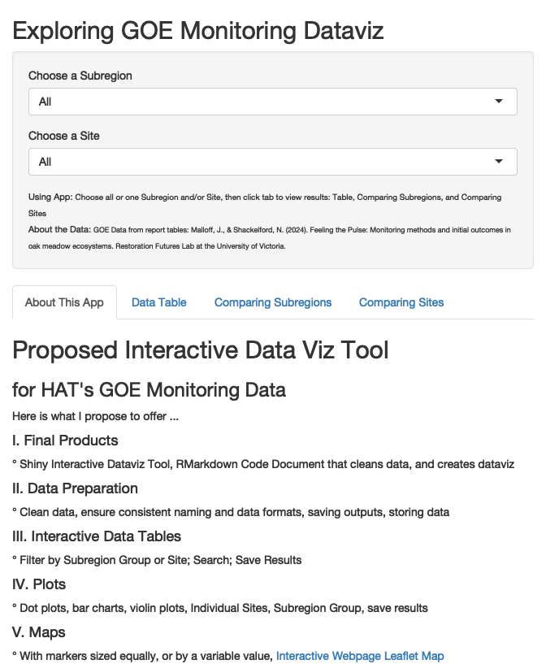

### 12.2.2 Reactive choose

```
## [1] "Subregion"                    "Site"
## [3] "Proportion_of_native_species" "Cultural_species_richness"
## [5] "Exotic_species"               "Trampling"
## [7] "Herbivory"                    "Composite_Index"
## [9] "Year"
```

```
## 'data.frame':    24 obs. of  9 variables:
##  $ Subregion                   : chr  "Gulf Islands" "Gulf Islands" "Gulf Islands" "Gulf Islands" ...
##  $ Site                        : chr  "Anniversary Island" "AVNR" "Brackman Island" "Crows Nest" ...
##  $ Proportion_of_native_species: num  0.94 0.55 0.77 0.66 0.75 0.53 0.45 0.65 0.62 0.58 ...
##  $ Cultural_species_richness   : num  2.71 1.3 2.8 1.07 3.6 0.8 0.42 2 3.6 2.33 ...
##  $ Exotic_species              : num  0.17 57.19 11.17 31.51 8.8 ...
##  $ Trampling                   : num  5 4.7 5.4 1.64 12.2 ...
##  $ Herbivory                   : num  1.14 36.5 0 26.71 0.1 ...
##  $ Composite_Index             : num  1.8 0.6 2 1 1.6 0.8 0.2 1.4 1 1 ...
##  $ Year                        : int  2023 2023 2023 2023 2023 2023 2023 2023 2023 2023 ...
```

```
##
## Listening on http://127.0.0.1:4709
```

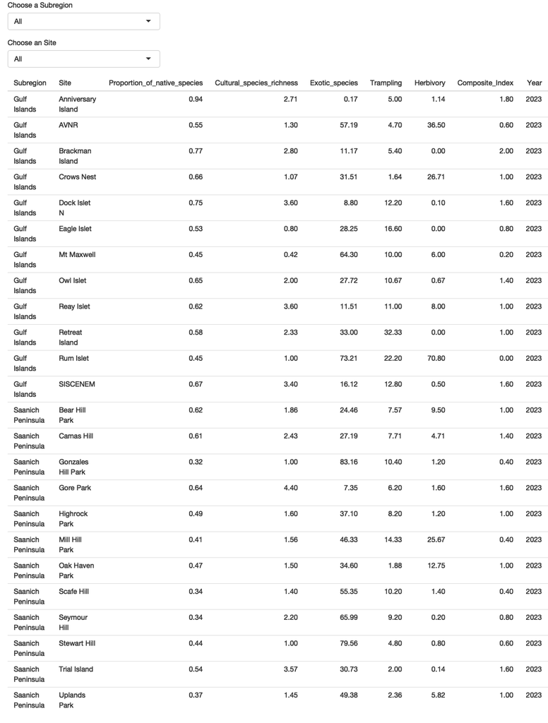